# Glue and S3 parameters

## Table analysis

The notebook uses the following Papermill parameters to update the notebook:

- `DatabaseName`: Name of the database
- `table_name`: Name of the table
- `partition_keys`: variables name to group to count the duplicates
- `keys`: Variable name to perform the grouping -> Only one variable for now, Variable name to perform the secondary grouping -> Only one variable for now
  - format: 'A,B'
- `proba`: Chi-square analysis probabilitity
- `y_var`: Continuous target variables
- `threshohld`: Percent of missing values. If the percentage of missing is above the threshold, their exclude from analysis.

Upload queries analytics

# Schema table

|  | Name | Type | Comment |
| --- | --- | --- | --- |
| 0 | geocode4_corr | string | city name |
| 1 | year | string | year |
| 2 | regime | varchar(12) | eligible or no eligible to vat rebate |
| 3 | hs6 | string | HS6 6 digit |
| 4 | hs4 | string | HS4 4 digit |
| 5 | hs3 | string | HS3 3 digit |
| 6 | hs2 | string | HS2 2 digit |
| 7 | homogeneous | string | Goods label |
| 8 | country_en | string | English country name |
| 9 | iso_alpha | string |  |
| 10 | gni_per_capita | float | GDP per capita is gross domestic product divided by midyear population |
| 11 | gpd_per_capita | float | GNI per capita (formerly GNP per capita) is the gross national income, converted to U.S. dollars using the World Bank Atlas method, divided by the midyear population |
| 12 | income_group | string | One of 'Others', 'Low income', 'Upper middle income','High income: nonOECD', 'Lower middle income', 'High income: OECD' |
| 13 | income_group_ldc_dc | varchar(3) | Income group LDC or not LDC in 2003 |
| 14 | quantity | bigint | Export quantity |
| 15 | value | bigint | Export value |
| 16 | unit_price | decimal(21,5) | product unit price |
| 17 | kandhelwal_quality | float | Kandhelwal quality |
| 18 | price_adjusted_quality | float | price adjusted |
| 19 | lag_vat_m | float | lag vat tax |
| 20 | lag_vat_reb_m | float | lag vat rebate |
| 21 | lag_tax_rebate | float | lag vat rebate to pay |
| 22 | ln_lag_vat_m | double | log lag vat tax |
| 23 | ln_lag_vat_reb_m | double | log lag vat rebate |
| 24 | ln_lag_tax_rebate | double | log lag vat rebate to pay |
| 25 | lag_import_tax | float | lag import tax |
| 26 | ln_lag_import_tax | double | log lag import tax |
| 27 | lag_soe_export_share_ckr | decimal(21,5) | lag export share city industry regime |
| 28 | lag_foreign_export_share_ckr | decimal(21,5) | lag export share city industry regime |
| 29 | high_tech | string | high tech product |
| 30 | energy | string | energy consuming product |
| 31 | skilled | string | skilled sectors |
| 32 | rd_oriented | string | rd_oriented sectors |
| 33 | count_hs6 | bigint | count hs6 |
| 34 | sum_quantity | bigint |  |
| 35 | city_average_hs6 | double |  |
| 36 | city_average_quantity | double |  |
| 37 | size_quantity | varchar(14) |  |
| 38 | size_product | varchar(11) |  |

## Check Duplicates

One of the most important step when creating a table is to check if the table contains duplicates. The cell below checks if the table generated before is empty of duplicates. The code uses the JSON file to create the query parsed in Athena.

You are required to define the group(s) that Athena will use to compute the duplicate. For instance, your table can be grouped by COL1 and COL2 (need to be string or varchar), then pass the list ['COL1', 'COL2']

|  | CNT | CNT_DUPLICATE |
| --- | --- | --- |
| 0 | 1 | 5744044 |

# Analytics

In this part, we are providing basic summary statistic. Since we have created the tables, we can parse the schema in Glue and use our json file to automatically generates the analysis.

The cells below execute the job in the key `ANALYSIS`. You need to change the `primary_key` and `secondary_key`

## Count missing values

|  | total_missing | total_missing_pct |
| --- | --- | --- |
| nb_obs | 5744044 | 100.00% |
| high_tech | 5698565 | 99.21% |
| skilled | 5605670 | 97.59% |
| rd_oriented | 5588060 | 97.28% |
| energy | 4086295 | 71.14% |
| gni_per_capita | 626838 | 10.91% |
| gpd_per_capita | 626838 | 10.91% |
| income_group | 626838 | 10.91% |
| lag_foreign_export_share_ckr | 0 | 0.00% |
| ln_lag_vat_reb_m | 0 | 0.00% |
| ln_lag_tax_rebate | 0 | 0.00% |
| lag_import_tax | 0 | 0.00% |
| ln_lag_import_tax | 0 | 0.00% |
| lag_soe_export_share_ckr | 0 | 0.00% |
| size_quantity | 0 | 0.00% |
| city_average_quantity | 0 | 0.00% |
| lag_tax_rebate | 0 | 0.00% |
| count_hs6 | 0 | 0.00% |
| sum_quantity | 0 | 0.00% |
| city_average_hs6 | 0 | 0.00% |
| ln_lag_vat_m | 0 | 0.00% |
| lag_vat_m | 0 | 0.00% |
| lag_vat_reb_m | 0 | 0.00% |
| geocode4_corr | 0 | 0.00% |
| year | 0 | 0.00% |
| regime | 0 | 0.00% |
| hs6 | 0 | 0.00% |
| hs4 | 0 | 0.00% |
| hs3 | 0 | 0.00% |
| hs2 | 0 | 0.00% |
| homogeneous | 0 | 0.00% |
| country_en | 0 | 0.00% |
| iso_alpha | 0 | 0.00% |
| income_group_ldc_dc | 0 | 0.00% |
| quantity | 0 | 0.00% |
| value | 0 | 0.00% |
| unit_price | 0 | 0.00% |
| kandhelwal_quality | 0 | 0.00% |
| price_adjusted_quality | 0 | 0.00% |
| size_product | 0 | 0.00% |

```
['high_tech',
 'skilled',
 'rd_oriented',
 'energy',
 'gni_per_capita',
 'gpd_per_capita',
 'income_group']
```

# Brief description table

In this part, we provide a brief summary statistic from the lattest jobs. For the continuous analysis with a primary/secondary key, please add the relevant variables you want to know the count and distribution

## Categorical Description

During the categorical analysis, we wil count the number of observations for a given group and for a pair.

### Count number of group

The table below shows the number of unique groups for each categorical variables, and print the first 10 groups, ordered alphabetically

|  | var | count | example |
| --- | --- | --- | --- |
| 0 | hs6 | 4686 | [100110, 100190, 100200, 100300, 100400, 100510, 100590, 100610, 100620, 100630] |
| 0 | hs4 | 1122 | [1001, 1002, 1003, 1004, 1005, 1006, 1007, 1008, 1101, 1102] |
| 0 | geocode4_corr | 270 | [1101, 1201, 1301, 1302, 1303, 1304, 1305, 1306, 1307, 1308] |
| 0 | country_en | 233 | [Afghanistan, Albania, Algeria, Andorra, Angola, Antigua and Barbuda, Argentina, Armenia, Aruba, Australia] |
| 0 | iso_alpha | 214 | [ABW, AFG, AGO, ALB, AND, ANT, ARG, ARM, ATG, AUS] |
| 0 | hs3 | 155 | [100, 110, 120, 121, 130, 140, 150, 151, 152, 160] |
| 0 | hs2 | 85 | [10, 11, 12, 13, 14, 15, 16, 17, 18, 19] |
| 0 | year | 8 | [2003, 2004, 2005, 2006, 2007, 2008, 2009, 2010] |
| 0 | homogeneous | 3 | [HETEREGENEOUS, HOMOGENEOUS, NA] |
| 0 | regime | 2 | [ELIGIBLE, NOT_ELIGIBLE] |
| 0 | income_group_ldc_dc | 2 | [DC, LDC] |
| 0 | size_quantity | 2 | [LARGE_QUANTITY, SMALL_QUANTITY] |
| 0 | size_product | 2 | [LARGE_COUNT, SMALL_COUNT] |

### Count obs by group

- Index: primary group
- nb_obs: Number of observations per primary group value
- percentage: Percentage of observation per primary group value over the total number of observations

Returns the top 10 only

```
Nb of obs for geocode4_corr, comment city name
```

| geocode4_corr | nb_obs | percentage |
| --- | --- | --- |
| 4403 | 538098 | 9.37% |
| 3101 | 526413 | 9.16% |
| 4419 | 332514 | 5.79% |
| 4401 | 249632 | 4.35% |
| 3302 | 225533 | 3.93% |
| 1101 | 189724 | 3.30% |
| 3301 | 178577 | 3.11% |
| 3702 | 165135 | 2.87% |
| 1201 | 154991 | 2.70% |
| 3201 | 150252 | 2.62% |

```
Nb of obs for year, comment year
```

| year | nb_obs | percentage |
| --- | --- | --- |
| 2007 | 974951 | 16.97% |
| 2008 | 814991 | 14.19% |
| 2010 | 809500 | 14.09% |
| 2009 | 787036 | 13.70% |
| 2005 | 702279 | 12.23% |
| 2006 | 685012 | 11.93% |
| 2004 | 544745 | 9.48% |
| 2003 | 425530 | 7.41% |

```
Nb of obs for regime, comment eligible or no eligible to vat rebate
```

| regime | nb_obs | percentage |
| --- | --- | --- |
| ELIGIBLE | 4851827 | 84.47% |
| NOT_ELIGIBLE | 892217 | 15.53% |

```
Nb of obs for hs6, comment HS6 6 digit
```

| hs6 | nb_obs | percentage |
| --- | --- | --- |
| 420212 | 21865 | 0.38% |
| 732690 | 20775 | 0.36% |
| 848180 | 17020 | 0.30% |
| 392640 | 16978 | 0.30% |
| 850440 | 16553 | 0.29% |
| 640299 | 15686 | 0.27% |
| 940540 | 15460 | 0.27% |
| 940320 | 15346 | 0.27% |
| 940360 | 15145 | 0.26% |
| 630790 | 15141 | 0.26% |

```
Nb of obs for hs4, comment HS4 4 digit
```

| hs4 | nb_obs | percentage |
| --- | --- | --- |
| 6204 | 82938 | 1.44% |
| 4202 | 81028 | 1.41% |
| 6104 | 75168 | 1.31% |
| 9403 | 71850 | 1.25% |
| 9401 | 63617 | 1.11% |
| 9405 | 62229 | 1.08% |
| 3926 | 53129 | 0.92% |
| 8708 | 52019 | 0.91% |
| 8516 | 49176 | 0.86% |
| 3923 | 47643 | 0.83% |

```
Nb of obs for hs3, comment HS3 3 digit
```

| hs3 | nb_obs | percentage |
| --- | --- | --- |
| 620 | 244943 | 4.26% |
| 940 | 237869 | 4.14% |
| 610 | 203366 | 3.54% |
| 392 | 188653 | 3.28% |
| 851 | 158395 | 2.76% |
| 841 | 152501 | 2.65% |
| 630 | 137150 | 2.39% |
| 850 | 133669 | 2.33% |
| 820 | 122776 | 2.14% |
| 853 | 122337 | 2.13% |

```
Nb of obs for hs2, comment HS2 2 digit
```

| hs2 | nb_obs | percentage |
| --- | --- | --- |
| 84 | 717843 | 12.50% |
| 85 | 538260 | 9.37% |
| 62 | 339295 | 5.91% |
| 61 | 308650 | 5.37% |
| 39 | 265783 | 4.63% |
| 73 | 260028 | 4.53% |
| 29 | 243109 | 4.23% |
| 94 | 237869 | 4.14% |
| 90 | 207852 | 3.62% |
| 82 | 178390 | 3.11% |

```
ISSUE: Nb of obs for homogeneous, comment Goods label
```

| homogeneous | nb_obs | percentage |
| --- | --- | --- |
| HETEREGENEOUS | 5486695 | 0.955197 |
| NaN | 223407 | 0.038894 |
| HOMOGENEOUS | 33942 | 0.005909 |

```
The variable homogeneous will be removed from analysis
Nb of obs for iso_alpha, comment iso_alpha
```

| iso_alpha | nb_obs | percentage |
| --- | --- | --- |
| USA | 293935 | 5.12% |
| HKG | 240118 | 4.18% |
| JPN | 200202 | 3.49% |
| DEU | 171222 | 2.98% |
| KOR | 149031 | 2.59% |
| AUS | 148564 | 2.59% |
| GBR | 146740 | 2.55% |
| ITA | 138861 | 2.42% |
| CAN | 132417 | 2.31% |
| ESP | 116481 | 2.03% |

```
Nb of obs for income_group_ldc_dc, comment Income group LDC or not LDC in 2003
```

| income_group_ldc_dc | nb_obs | percentage |
| --- | --- | --- |
| DC | 5233172 | 91.11% |
| LDC | 510872 | 8.89% |

```
Nb of obs for size_quantity, comment size_quantity
```

| size_quantity | nb_obs | percentage |
| --- | --- | --- |
| LARGE_QUANTITY | 4396364 | 76.54% |
| SMALL_QUANTITY | 1347680 | 23.46% |

```
Nb of obs for size_product, comment size_product
```

| size_product | nb_obs | percentage |
| --- | --- | --- |
| LARGE_COUNT | 5317195 | 92.57% |
| SMALL_COUNT | 426849 | 7.43% |

### Count obs by two pair

You need to pass the primary group in the cell below

- Index: primary group
- Columns: Secondary key -> All the categorical variables in the dataset
- nb_obs: Number of observations per primary group value
- Total: Total number of observations per primary group value (sum by row)
- percentage: Percentage of observations per primary group value over the total number of observations per primary group value (sum by row)

Returns the top 10 only

```
Nb of obs for the primary group year and geocode4_corr, details city name
```

| year geocode4_corr | nb_obs 2003 | nb_obs 2004 | nb_obs 2005 | nb_obs 2006 | nb_obs 2007 | nb_obs 2008 | nb_obs 2009 | nb_obs 2010 | total | percentage 2003 | percentage 2004 | percentage 2005 | percentage 2006 | percentage 2007 | percentage 2008 | percentage 2009 | percentage 2010 |
| --- | --- | --- | --- | --- | --- | --- | --- | --- | --- | --- | --- | --- | --- | --- | --- | --- | --- |
| 1101 | 12,382.00 | 15,602.00 | 22,588.00 | 23,678.00 | 33,469.00 | 25,501.00 | 25,701.00 | 30,803.00 | 189,724.00 | 6.53% | 8.22% | 11.91% | 12.48% | 17.64% | 13.44% | 13.55% | 16.24% |
| 1201 | 9,620.00 | 12,079.00 | 14,930.00 | 15,272.00 | 31,762.00 | 24,738.00 | 23,072.00 | 23,518.00 | 154,991.00 | 6.21% | 7.79% | 9.63% | 9.85% | 20.49% | 15.96% | 14.89% | 15.17% |
| 3101 | 31,489.00 | 41,343.00 | 48,577.00 | 51,313.00 | 98,103.00 | 78,580.00 | 88,868.00 | 88,140.00 | 526,413.00 | 5.98% | 7.85% | 9.23% | 9.75% | 18.64% | 14.93% | 16.88% | 16.74% |
| 3201 | 15,523.00 | 18,630.00 | 22,130.00 | 20,774.00 | 20,073.00 | 15,923.00 | 17,641.00 | 19,558.00 | 150,252.00 | 10.33% | 12.40% | 14.73% | 13.83% | 13.36% | 10.60% | 11.74% | 13.02% |
| 3301 | 16,760.00 | 20,569.00 | 24,948.00 | 25,682.00 | 27,063.00 | 19,856.00 | 20,379.00 | 23,320.00 | 178,577.00 | 9.39% | 11.52% | 13.97% | 14.38% | 15.15% | 11.12% | 11.41% | 13.06% |
| 3302 | 15,241.00 | 20,033.00 | 30,093.00 | 29,836.00 | 39,554.00 | 28,086.00 | 28,652.00 | 34,038.00 | 225,533.00 | 6.76% | 8.88% | 13.34% | 13.23% | 17.54% | 12.45% | 12.70% | 15.09% |
| 3702 | 14,353.00 | 17,776.00 | 20,417.00 | 20,334.00 | 28,205.00 | 21,523.00 | 20,681.00 | 21,846.00 | 165,135.00 | 8.69% | 10.76% | 12.36% | 12.31% | 17.08% | 13.03% | 12.52% | 13.23% |
| 4401 | 22,492.00 | 27,492.00 | 34,957.00 | 29,622.00 | 39,623.00 | 29,676.00 | 36,116.00 | 29,654.00 | 249,632.00 | 9.01% | 11.01% | 14.00% | 11.87% | 15.87% | 11.89% | 14.47% | 11.88% |
| 4403 | 28,176.00 | 33,778.00 | 47,831.00 | 40,624.00 | 94,674.00 | 125,703.00 | 83,672.00 | 83,640.00 | 538,098.00 | 5.24% | 6.28% | 8.89% | 7.55% | 17.59% | 23.36% | 15.55% | 15.54% |
| 4419 | 24,844.00 | 22,865.00 | 27,094.00 | 22,204.00 | 60,400.00 | 62,692.00 | 61,519.00 | 50,896.00 | 332,514.00 | 7.47% | 6.88% | 8.15% | 6.68% | 18.16% | 18.85% | 18.50% | 15.31% |

```
Nb of obs for the primary group year and regime, details eligible or no eligible to vat rebate
```

| year | nb_obs 2003 | nb_obs 2004 | nb_obs 2005 | nb_obs 2006 | nb_obs 2007 | nb_obs 2008 | nb_obs 2009 | nb_obs 2010 | total | percentage 2003 | percentage 2004 | percentage 2005 | percentage 2006 | percentage 2007 | percentage 2008 | percentage 2009 | percentage 2010 |
| --- | --- | --- | --- | --- | --- | --- | --- | --- | --- | --- | --- | --- | --- | --- | --- | --- | --- |
| NOT_ELIGIBLE | 31,762.00 | 32,775.00 | 35,720.00 | 33,433.00 | 207,768.00 | 161,709.00 | 193,422.00 | 195,628.00 | 892,217.00 | 3.56% | 3.67% | 4.00% | 3.75% | 23.29% | 18.12% | 21.68% | 21.93% |
| ELIGIBLE | 393,768.00 | 511,970.00 | 666,559.00 | 651,579.00 | 767,183.00 | 653,282.00 | 593,614.00 | 613,872.00 | 4,851,827.00 | 8.12% | 10.55% | 13.74% | 13.43% | 15.81% | 13.46% | 12.23% | 12.65% |

```
Nb of obs for the primary group year and hs6, details HS6 6 digit
```

| year hs6 | nb_obs 2003 | nb_obs 2004 | nb_obs 2005 | nb_obs 2006 | nb_obs 2007 | nb_obs 2008 | nb_obs 2009 | nb_obs 2010 | total | percentage 2003 | percentage 2004 | percentage 2005 | percentage 2006 | percentage 2007 | percentage 2008 | percentage 2009 | percentage 2010 |
| --- | --- | --- | --- | --- | --- | --- | --- | --- | --- | --- | --- | --- | --- | --- | --- | --- | --- |
| 392640 | 1,692.00 | 2,082.00 | 1,960.00 | 1,760.00 | 3,212.00 | 2,124.00 | 2,191.00 | 1,957.00 | 16,978.00 | 9.97% | 12.26% | 11.54% | 10.37% | 18.92% | 12.51% | 12.90% | 11.53% |
| 420212 | 1,978.00 | 2,282.00 | 2,448.00 | 2,166.00 | 3,997.00 | 2,952.00 | 3,073.00 | 2,969.00 | 21,865.00 | 9.05% | 10.44% | 11.20% | 9.91% | 18.28% | 13.50% | 14.05% | 13.58% |
| 630790 | 1,126.00 | 1,389.00 | 1,784.00 | 1,781.00 | 2,443.00 | 2,062.00 | 2,277.00 | 2,279.00 | 15,141.00 | 7.44% | 9.17% | 11.78% | 11.76% | 16.13% | 13.62% | 15.04% | 15.05% |
| 640299 | 1,192.00 | 1,358.00 | 1,567.00 | 1,499.00 | 2,768.00 | 2,232.00 | 2,461.00 | 2,609.00 | 15,686.00 | 7.60% | 8.66% | 9.99% | 9.56% | 17.65% | 14.23% | 15.69% | 16.63% |
| 732690 | 1,678.00 | 2,053.00 | 2,577.00 | 2,511.00 | 3,464.00 | 2,733.00 | 2,823.00 | 2,936.00 | 20,775.00 | 8.08% | 9.88% | 12.40% | 12.09% | 16.67% | 13.16% | 13.59% | 14.13% |
| 848180 | 1,065.00 | 1,321.00 | 1,683.00 | 1,740.00 | 2,979.00 | 2,661.00 | 2,673.00 | 2,898.00 | 17,020.00 | 6.26% | 7.76% | 9.89% | 10.22% | 17.50% | 15.63% | 15.71% | 17.03% |
| 850440 | 903.00 | 1,220.00 | 1,447.00 | 1,520.00 | 2,941.00 | 2,089.00 | 3,085.00 | 3,348.00 | 16,553.00 | 5.46% | 7.37% | 8.74% | 9.18% | 17.77% | 12.62% | 18.64% | 20.23% |
| 940320 | 965.00 | 1,300.00 | 1,682.00 | 1,692.00 | 2,942.00 | 2,218.00 | 2,152.00 | 2,395.00 | 15,346.00 | 6.29% | 8.47% | 10.96% | 11.03% | 19.17% | 14.45% | 14.02% | 15.61% |
| 940360 | 1,008.00 | 1,402.00 | 1,752.00 | 1,783.00 | 2,725.00 | 2,052.00 | 2,095.00 | 2,328.00 | 15,145.00 | 6.66% | 9.26% | 11.57% | 11.77% | 17.99% | 13.55% | 13.83% | 15.37% |
| 940540 | 1,255.00 | 1,495.00 | 1,750.00 | 1,606.00 | 2,987.00 | 2,331.00 | 1,955.00 | 2,081.00 | 15,460.00 | 8.12% | 9.67% | 11.32% | 10.39% | 19.32% | 15.08% | 12.65% | 13.46% |

```
Nb of obs for the primary group year and hs4, details HS4 4 digit
```

| year hs4 | nb_obs 2003 | nb_obs 2004 | nb_obs 2005 | nb_obs 2006 | nb_obs 2007 | nb_obs 2008 | nb_obs 2009 | nb_obs 2010 | total | percentage 2003 | percentage 2004 | percentage 2005 | percentage 2006 | percentage 2007 | percentage 2008 | percentage 2009 | percentage 2010 |
| --- | --- | --- | --- | --- | --- | --- | --- | --- | --- | --- | --- | --- | --- | --- | --- | --- | --- |
| 3923 | 3,341.00 | 4,427.00 | 5,750.00 | 5,686.00 | 8,524.00 | 6,215.00 | 6,759.00 | 6,941.00 | 47,643.00 | 7.01% | 9.29% | 12.07% | 11.93% | 17.89% | 13.04% | 14.19% | 14.57% |
| 3926 | 6,041.00 | 7,599.00 | 8,282.00 | 7,897.00 | 7,732.00 | 5,055.00 | 5,375.00 | 5,148.00 | 53,129.00 | 11.37% | 14.30% | 15.59% | 14.86% | 14.55% | 9.51% | 10.12% | 9.69% |
| 4202 | 6,801.00 | 8,555.00 | 9,520.00 | 8,494.00 | 15,120.00 | 10,480.00 | 10,969.00 | 11,089.00 | 81,028.00 | 8.39% | 10.56% | 11.75% | 10.48% | 18.66% | 12.93% | 13.54% | 13.69% |
| 6104 | 5,755.00 | 7,183.00 | 9,027.00 | 7,989.00 | 12,242.00 | 10,176.00 | 10,995.00 | 11,801.00 | 75,168.00 | 7.66% | 9.56% | 12.01% | 10.63% | 16.29% | 13.54% | 14.63% | 15.70% |
| 6204 | 6,513.00 | 7,774.00 | 10,600.00 | 9,762.00 | 14,019.00 | 11,745.00 | 11,437.00 | 11,088.00 | 82,938.00 | 7.85% | 9.37% | 12.78% | 11.77% | 16.90% | 14.16% | 13.79% | 13.37% |
| 8516 | 2,725.00 | 3,328.00 | 4,005.00 | 3,736.00 | 9,469.00 | 8,105.00 | 8,925.00 | 8,883.00 | 49,176.00 | 5.54% | 6.77% | 8.14% | 7.60% | 19.26% | 16.48% | 18.15% | 18.06% |
| 8708 | 3,337.00 | 5,151.00 | 7,617.00 | 7,774.00 | 7,148.00 | 7,208.00 | 6,922.00 | 6,862.00 | 52,019.00 | 6.41% | 9.90% | 14.64% | 14.94% | 13.74% | 13.86% | 13.31% | 13.19% |
| 9401 | 3,722.00 | 5,376.00 | 6,994.00 | 6,557.00 | 12,253.00 | 9,186.00 | 9,105.00 | 10,424.00 | 63,617.00 | 5.85% | 8.45% | 10.99% | 10.31% | 19.26% | 14.44% | 14.31% | 16.39% |
| 9403 | 4,787.00 | 6,613.00 | 8,547.00 | 8,284.00 | 11,937.00 | 10,314.00 | 10,509.00 | 10,859.00 | 71,850.00 | 6.66% | 9.20% | 11.90% | 11.53% | 16.61% | 14.35% | 14.63% | 15.11% |
| 9405 | 5,063.00 | 6,203.00 | 7,231.00 | 6,647.00 | 11,522.00 | 8,541.00 | 8,472.00 | 8,550.00 | 62,229.00 | 8.14% | 9.97% | 11.62% | 10.68% | 18.52% | 13.73% | 13.61% | 13.74% |

```
Nb of obs for the primary group year and hs3, details HS3 3 digit
```

| year hs3 | nb_obs 2003 | nb_obs 2004 | nb_obs 2005 | nb_obs 2006 | nb_obs 2007 | nb_obs 2008 | nb_obs 2009 | nb_obs 2010 | total | percentage 2003 | percentage 2004 | percentage 2005 | percentage 2006 | percentage 2007 | percentage 2008 | percentage 2009 | percentage 2010 |
| --- | --- | --- | --- | --- | --- | --- | --- | --- | --- | --- | --- | --- | --- | --- | --- | --- | --- |
| 392 | 14,995.00 | 20,217.00 | 24,561.00 | 23,946.00 | 32,781.00 | 23,091.00 | 24,138.00 | 24,924.00 | 188,653.00 | 7.95% | 10.72% | 13.02% | 12.69% | 17.38% | 12.24% | 12.79% | 13.21% |
| 610 | 16,611.00 | 20,096.00 | 27,262.00 | 23,153.00 | 34,233.00 | 27,934.00 | 26,836.00 | 27,241.00 | 203,366.00 | 8.17% | 9.88% | 13.41% | 11.38% | 16.83% | 13.74% | 13.20% | 13.40% |
| 620 | 20,992.00 | 24,729.00 | 31,813.00 | 29,019.00 | 40,154.00 | 34,608.00 | 32,298.00 | 31,330.00 | 244,943.00 | 8.57% | 10.10% | 12.99% | 11.85% | 16.39% | 14.13% | 13.19% | 12.79% |
| 630 | 11,007.00 | 13,784.00 | 17,466.00 | 16,366.00 | 21,857.00 | 19,436.00 | 18,708.00 | 18,526.00 | 137,150.00 | 8.03% | 10.05% | 12.73% | 11.93% | 15.94% | 14.17% | 13.64% | 13.51% |
| 820 | 9,778.00 | 11,536.00 | 15,053.00 | 14,328.00 | 20,895.00 | 17,218.00 | 16,788.00 | 17,180.00 | 122,776.00 | 7.96% | 9.40% | 12.26% | 11.67% | 17.02% | 14.02% | 13.67% | 13.99% |
| 841 | 8,566.00 | 11,558.00 | 15,690.00 | 16,858.00 | 26,140.00 | 23,887.00 | 23,547.00 | 26,255.00 | 152,501.00 | 5.62% | 7.58% | 10.29% | 11.05% | 17.14% | 15.66% | 15.44% | 17.22% |
| 850 | 8,719.00 | 11,012.00 | 13,695.00 | 14,795.00 | 22,780.00 | 19,452.00 | 20,665.00 | 22,551.00 | 133,669.00 | 6.52% | 8.24% | 10.25% | 11.07% | 17.04% | 14.55% | 15.46% | 16.87% |
| 851 | 10,751.00 | 13,104.00 | 16,589.00 | 15,818.00 | 27,219.00 | 22,793.00 | 25,635.00 | 26,486.00 | 158,395.00 | 6.79% | 8.27% | 10.47% | 9.99% | 17.18% | 14.39% | 16.18% | 16.72% |
| 853 | 8,387.00 | 10,277.00 | 12,819.00 | 12,298.00 | 20,367.00 | 18,670.00 | 18,611.00 | 20,908.00 | 122,337.00 | 6.86% | 8.40% | 10.48% | 10.05% | 16.65% | 15.26% | 15.21% | 17.09% |
| 940 | 15,946.00 | 21,494.00 | 27,366.00 | 26,222.00 | 43,324.00 | 34,131.00 | 33,805.00 | 35,581.00 | 237,869.00 | 6.70% | 9.04% | 11.50% | 11.02% | 18.21% | 14.35% | 14.21% | 14.96% |

```
Nb of obs for the primary group year and hs2, details HS2 2 digit
```

| year hs2 | nb_obs 2003 | nb_obs 2004 | nb_obs 2005 | nb_obs 2006 | nb_obs 2007 | nb_obs 2008 | nb_obs 2009 | nb_obs 2010 | total | percentage 2003 | percentage 2004 | percentage 2005 | percentage 2006 | percentage 2007 | percentage 2008 | percentage 2009 | percentage 2010 |
| --- | --- | --- | --- | --- | --- | --- | --- | --- | --- | --- | --- | --- | --- | --- | --- | --- | --- |
| 29 | 21,942.00 | 26,614.00 | 32,964.00 | 35,796.00 | 35,852.00 | 30,391.00 | 29,882.00 | 29,668.00 | 243,109.00 | 9.03% | 10.95% | 13.56% | 14.72% | 14.75% | 12.50% | 12.29% | 12.20% |
| 39 | 18,761.00 | 25,826.00 | 32,813.00 | 32,700.00 | 46,821.00 | 34,961.00 | 36,195.00 | 37,706.00 | 265,783.00 | 7.06% | 9.72% | 12.35% | 12.30% | 17.62% | 13.15% | 13.62% | 14.19% |
| 61 | 25,859.00 | 31,107.00 | 42,165.00 | 35,919.00 | 51,053.00 | 41,592.00 | 40,239.00 | 40,716.00 | 308,650.00 | 8.38% | 10.08% | 13.66% | 11.64% | 16.54% | 13.48% | 13.04% | 13.19% |
| 62 | 28,912.00 | 34,346.00 | 44,430.00 | 40,122.00 | 55,896.00 | 47,377.00 | 44,546.00 | 43,666.00 | 339,295.00 | 8.52% | 10.12% | 13.09% | 11.83% | 16.47% | 13.96% | 13.13% | 12.87% |
| 73 | 18,233.00 | 23,553.00 | 31,238.00 | 32,219.00 | 45,816.00 | 37,014.00 | 36,039.00 | 35,916.00 | 260,028.00 | 7.01% | 9.06% | 12.01% | 12.39% | 17.62% | 14.23% | 13.86% | 13.81% |
| 82 | 14,261.00 | 17,008.00 | 21,341.00 | 19,892.00 | 32,316.00 | 24,370.00 | 24,482.00 | 24,720.00 | 178,390.00 | 7.99% | 9.53% | 11.96% | 11.15% | 18.12% | 13.66% | 13.72% | 13.86% |
| 84 | 42,270.00 | 56,462.00 | 78,456.00 | 82,389.00 | 120,185.00 | 114,598.00 | 107,129.00 | 116,354.00 | 717,843.00 | 5.89% | 7.87% | 10.93% | 11.48% | 16.74% | 15.96% | 14.92% | 16.21% |
| 85 | 38,259.00 | 47,479.00 | 60,018.00 | 60,507.00 | 86,669.00 | 76,360.00 | 81,571.00 | 87,397.00 | 538,260.00 | 7.11% | 8.82% | 11.15% | 11.24% | 16.10% | 14.19% | 15.15% | 16.24% |
| 90 | 13,131.00 | 17,259.00 | 23,101.00 | 23,491.00 | 34,594.00 | 31,296.00 | 31,531.00 | 33,449.00 | 207,852.00 | 6.32% | 8.30% | 11.11% | 11.30% | 16.64% | 15.06% | 15.17% | 16.09% |
| 94 | 15,946.00 | 21,494.00 | 27,366.00 | 26,222.00 | 43,324.00 | 34,131.00 | 33,805.00 | 35,581.00 | 237,869.00 | 6.70% | 9.04% | 11.50% | 11.02% | 18.21% | 14.35% | 14.21% | 14.96% |

```
Nb of obs for the primary group year and country_en, details English country name
```

| year | nb_obs 2003 | nb_obs 2004 | nb_obs 2005 | nb_obs 2006 | nb_obs 2007 | nb_obs 2008 | nb_obs 2009 | nb_obs 2010 | total | percentage 2003 | percentage 2004 | percentage 2005 | percentage 2006 | percentage 2007 | percentage 2008 | percentage 2009 | percentage 2010 |
| --- | --- | --- | --- | --- | --- | --- | --- | --- | --- | --- | --- | --- | --- | --- | --- | --- | --- |
| Spain | 7,972.00 | 10,150.00 | 13,985.00 | 14,167.00 | 20,357.00 | 17,201.00 | 16,165.00 | 16,484.00 | 116,481.00 | 6.84% | 8.71% | 12.01% | 12.16% | 17.48% | 14.77% | 13.88% | 14.15% |
| Canada | 9,971.00 | 12,137.00 | 16,462.00 | 16,339.00 | 23,187.00 | 18,097.00 | 17,707.00 | 18,517.00 | 132,417.00 | 7.53% | 9.17% | 12.43% | 12.34% | 17.51% | 13.67% | 13.37% | 13.98% |
| Italy | 10,215.00 | 12,789.00 | 17,356.00 | 17,161.00 | 23,208.00 | 19,903.00 | 19,109.00 | 19,120.00 | 138,861.00 | 7.36% | 9.21% | 12.50% | 12.36% | 16.71% | 14.33% | 13.76% | 13.77% |
| United Kingdom | 11,084.00 | 14,048.00 | 18,243.00 | 17,566.00 | 24,734.00 | 19,642.00 | 20,279.00 | 21,144.00 | 146,740.00 | 7.55% | 9.57% | 12.43% | 11.97% | 16.86% | 13.39% | 13.82% | 14.41% |
| Australia | 12,002.00 | 15,133.00 | 18,737.00 | 17,873.00 | 24,008.00 | 19,787.00 | 20,151.00 | 20,873.00 | 148,564.00 | 8.08% | 10.19% | 12.61% | 12.03% | 16.16% | 13.32% | 13.56% | 14.05% |
| Germany | 12,614.00 | 15,773.00 | 20,918.00 | 20,571.00 | 29,085.00 | 23,788.00 | 24,034.00 | 24,439.00 | 171,222.00 | 7.37% | 9.21% | 12.22% | 12.01% | 16.99% | 13.89% | 14.04% | 14.27% |
| Korea | 17,127.00 | 20,061.00 | 25,121.00 | 23,278.00 | 28,815.00 | 21,179.00 | 18,369.00 | 19,082.00 | 173,032.00 | 9.90% | 11.59% | 14.52% | 13.45% | 16.65% | 12.24% | 10.62% | 11.03% |
| Japan | 20,785.00 | 24,134.00 | 27,906.00 | 25,286.00 | 30,302.00 | 24,601.00 | 23,610.00 | 23,578.00 | 200,202.00 | 10.38% | 12.05% | 13.94% | 12.63% | 15.14% | 12.29% | 11.79% | 11.78% |
| Hong Kong | 28,689.00 | 31,364.00 | 32,353.00 | 27,960.00 | 43,632.00 | 22,767.00 | 27,164.00 | 26,189.00 | 240,118.00 | 11.95% | 13.06% | 13.47% | 11.64% | 18.17% | 9.48% | 11.31% | 10.91% |
| United States | 25,409.00 | 30,020.00 | 38,523.00 | 36,669.00 | 48,845.00 | 37,789.00 | 37,280.00 | 39,400.00 | 293,935.00 | 8.64% | 10.21% | 13.11% | 12.48% | 16.62% | 12.86% | 12.68% | 13.40% |

```
Nb of obs for the primary group year and iso_alpha, details iso_alpha
```

| year | nb_obs 2003 | nb_obs 2004 | nb_obs 2005 | nb_obs 2006 | nb_obs 2007 | nb_obs 2008 | nb_obs 2009 | nb_obs 2010 | total | percentage 2003 | percentage 2004 | percentage 2005 | percentage 2006 | percentage 2007 | percentage 2008 | percentage 2009 | percentage 2010 |
| --- | --- | --- | --- | --- | --- | --- | --- | --- | --- | --- | --- | --- | --- | --- | --- | --- | --- |
| ESP | 7,972.00 | 10,150.00 | 13,985.00 | 14,167.00 | 20,357.00 | 17,201.00 | 16,165.00 | 16,484.00 | 116,481.00 | 6.84% | 8.71% | 12.01% | 12.16% | 17.48% | 14.77% | 13.88% | 14.15% |
| CAN | 9,971.00 | 12,137.00 | 16,462.00 | 16,339.00 | 23,187.00 | 18,097.00 | 17,707.00 | 18,517.00 | 132,417.00 | 7.53% | 9.17% | 12.43% | 12.34% | 17.51% | 13.67% | 13.37% | 13.98% |
| ITA | 10,215.00 | 12,789.00 | 17,356.00 | 17,161.00 | 23,208.00 | 19,903.00 | 19,109.00 | 19,120.00 | 138,861.00 | 7.36% | 9.21% | 12.50% | 12.36% | 16.71% | 14.33% | 13.76% | 13.77% |
| GBR | 11,084.00 | 14,048.00 | 18,243.00 | 17,566.00 | 24,734.00 | 19,642.00 | 20,279.00 | 21,144.00 | 146,740.00 | 7.55% | 9.57% | 12.43% | 11.97% | 16.86% | 13.39% | 13.82% | 14.41% |
| AUS | 12,002.00 | 15,133.00 | 18,737.00 | 17,873.00 | 24,008.00 | 19,787.00 | 20,151.00 | 20,873.00 | 148,564.00 | 8.08% | 10.19% | 12.61% | 12.03% | 16.16% | 13.32% | 13.56% | 14.05% |
| KOR | 15,294.00 | 17,630.00 | 21,715.00 | 21,032.00 | 23,784.00 | 18,308.00 | 15,482.00 | 15,786.00 | 149,031.00 | 10.26% | 11.83% | 14.57% | 14.11% | 15.96% | 12.28% | 10.39% | 10.59% |
| DEU | 12,614.00 | 15,773.00 | 20,918.00 | 20,571.00 | 29,085.00 | 23,788.00 | 24,034.00 | 24,439.00 | 171,222.00 | 7.37% | 9.21% | 12.22% | 12.01% | 16.99% | 13.89% | 14.04% | 14.27% |
| JPN | 20,785.00 | 24,134.00 | 27,906.00 | 25,286.00 | 30,302.00 | 24,601.00 | 23,610.00 | 23,578.00 | 200,202.00 | 10.38% | 12.05% | 13.94% | 12.63% | 15.14% | 12.29% | 11.79% | 11.78% |
| HKG | 28,689.00 | 31,364.00 | 32,353.00 | 27,960.00 | 43,632.00 | 22,767.00 | 27,164.00 | 26,189.00 | 240,118.00 | 11.95% | 13.06% | 13.47% | 11.64% | 18.17% | 9.48% | 11.31% | 10.91% |
| USA | 25,409.00 | 30,020.00 | 38,523.00 | 36,669.00 | 48,845.00 | 37,789.00 | 37,280.00 | 39,400.00 | 293,935.00 | 8.64% | 10.21% | 13.11% | 12.48% | 16.62% | 12.86% | 12.68% | 13.40% |

```
Nb of obs for the primary group year and income_group_ldc_dc, details Income group LDC or not LDC in 2003
```

| year | nb_obs 2003 | nb_obs 2004 | nb_obs 2005 | nb_obs 2006 | nb_obs 2007 | nb_obs 2008 | nb_obs 2009 | nb_obs 2010 | total | percentage 2003 | percentage 2004 | percentage 2005 | percentage 2006 | percentage 2007 | percentage 2008 | percentage 2009 | percentage 2010 |
| --- | --- | --- | --- | --- | --- | --- | --- | --- | --- | --- | --- | --- | --- | --- | --- | --- | --- |
| LDC | 34,890.00 | 48,255.00 | 62,365.00 | 49,712.00 | 90,672.00 | 75,487.00 | 74,120.00 | 75,371.00 | 510,872.00 | 6.83% | 9.45% | 12.21% | 9.73% | 17.75% | 14.78% | 14.51% | 14.75% |
| DC | 390,640.00 | 496,490.00 | 639,914.00 | 635,300.00 | 884,279.00 | 739,504.00 | 712,916.00 | 734,129.00 | 5,233,172.00 | 7.46% | 9.49% | 12.23% | 12.14% | 16.90% | 14.13% | 13.62% | 14.03% |

```
Nb of obs for the primary group year and size_quantity, details size_quantity
```

| year | nb_obs 2003 | nb_obs 2004 | nb_obs 2005 | nb_obs 2006 | nb_obs 2007 | nb_obs 2008 | nb_obs 2009 | nb_obs 2010 | total | percentage 2003 | percentage 2004 | percentage 2005 | percentage 2006 | percentage 2007 | percentage 2008 | percentage 2009 | percentage 2010 |
| --- | --- | --- | --- | --- | --- | --- | --- | --- | --- | --- | --- | --- | --- | --- | --- | --- | --- |
| SMALL_QUANTITY | 108,530.00 | 151,740.00 | 197,768.00 | 198,786.00 | 207,245.00 | 153,478.00 | 164,534.00 | 165,599.00 | 1,347,680.00 | 8.05% | 11.26% | 14.67% | 14.75% | 15.38% | 11.39% | 12.21% | 12.29% |
| LARGE_QUANTITY | 317,000.00 | 393,005.00 | 504,511.00 | 486,226.00 | 767,706.00 | 661,513.00 | 622,502.00 | 643,901.00 | 4,396,364.00 | 7.21% | 8.94% | 11.48% | 11.06% | 17.46% | 15.05% | 14.16% | 14.65% |

```
Nb of obs for the primary group year and size_product, details size_product
```

| year | nb_obs 2003 | nb_obs 2004 | nb_obs 2005 | nb_obs 2006 | nb_obs 2007 | nb_obs 2008 | nb_obs 2009 | nb_obs 2010 | total | percentage 2003 | percentage 2004 | percentage 2005 | percentage 2006 | percentage 2007 | percentage 2008 | percentage 2009 | percentage 2010 |
| --- | --- | --- | --- | --- | --- | --- | --- | --- | --- | --- | --- | --- | --- | --- | --- | --- | --- |
| SMALL_COUNT | 42,407.00 | 56,976.00 | 72,506.00 | 77,028.00 | 58,064.00 | 37,952.00 | 39,629.00 | 42,287.00 | 426,849.00 | 9.93% | 13.35% | 16.99% | 18.05% | 13.60% | 8.89% | 9.28% | 9.91% |
| LARGE_COUNT | 383,123.00 | 487,769.00 | 629,773.00 | 607,984.00 | 916,887.00 | 777,039.00 | 747,407.00 | 767,213.00 | 5,317,195.00 | 7.21% | 9.17% | 11.84% | 11.43% | 17.24% | 14.61% | 14.06% | 14.43% |

## Continuous description

There are three possibilities to show the ditribution of a continuous variables:

1. Display the percentile
2. Display the percentile, with one primary key
3. Display the percentile, with one primary key, and a secondary key

### 1. Display the percentile

| pct | quantity | value | unit_price | kandhelwal_quality | price_adjusted_quality | lag_vat_m | lag_vat_reb_m | lag_tax_rebate | ln_lag_vat_m | ln_lag_vat_reb_m | ln_lag_tax_rebate | lag_import_tax | ln_lag_import_tax | lag_soe_export_share_ckr | lag_foreign_export_share_ckr | count_hs6 | sum_quantity | city_average_hs6 | city_average_quantity |
| --- | --- | --- | --- | --- | --- | --- | --- | --- | --- | --- | --- | --- | --- | --- | --- | --- | --- | --- | --- |
| 0.01 | 1.00 | 30.00 | 0.06 | -6.75 | -5.00 | 14.62 | 0.00 | 0.00 | 2.74 | 0.00 | 0.00 | 0.00 | 0.00 | 0.00 | 0.00 | 60.00 | 18533043.00 | 329.24 | 556454605.61 |
| 0.05 | 5.00 | 233.00 | 0.28 | -3.20 | -1.73 | 17.00 | 5.00 | 0.00 | 2.89 | 1.79 | 0.00 | 0.00 | 0.00 | 0.00 | 0.00 | 211.00 | 104201302.00 | 329.24 | 556454605.61 |
| 0.1 | 28.00 | 651.00 | 0.53 | -2.14 | -0.81 | 17.00 | 8.42 | 0.00 | 2.89 | 2.24 | 0.00 | 4.00 | 1.61 | 0.00 | 0.00 | 423.00 | 237563360.00 | 329.24 | 556454605.61 |
| 0.2 | 200.00 | 2047.00 | 1.03 | -1.19 | -0.02 | 17.00 | 12.00 | 2.00 | 2.89 | 2.56 | 1.10 | 6.00 | 1.95 | 0.00 | 0.00 | 837.00 | 412072549.00 | 329.24 | 556454605.61 |
| 0.25 | 383.00 | 3071.00 | 1.31 | -0.89 | 0.25 | 17.00 | 12.00 | 2.50 | 2.89 | 2.56 | 1.25 | 6.50 | 2.01 | 0.00 | 0.00 | 979.00 | 611032609.00 | 329.24 | 556454605.61 |
| 0.3 | 651.00 | 4447.00 | 1.62 | -0.65 | 0.50 | 17.00 | 13.00 | 4.00 | 2.89 | 2.64 | 1.61 | 8.00 | 2.18 | 0.00 | 0.00 | 1074.00 | 870622440.00 | 329.24 | 556454605.61 |
| 0.4 | 1631.00 | 8447.00 | 2.39 | -0.27 | 0.92 | 17.00 | 13.00 | 4.00 | 2.89 | 2.64 | 1.61 | 9.50 | 2.35 | 0.00 | 0.00 | 1236.00 | 1505692610.00 | 329.24 | 556454605.61 |
| 0.5 | 3583.00 | 15103.00 | 3.49 | 0.06 | 1.32 | 17.00 | 13.00 | 4.00 | 2.89 | 2.64 | 1.61 | 10.00 | 2.40 | 0.02 | 0.00 | 1628.00 | 1979565893.00 | 329.24 | 556454605.61 |
| 0.6 | 7583.00 | 26527.00 | 5.22 | 0.37 | 1.76 | 17.00 | 13.00 | 4.00 | 2.89 | 2.64 | 1.61 | 12.00 | 2.56 | 0.06 | 0.00 | 2048.00 | 2743791316.00 | 329.24 | 556454605.61 |
| 0.7 | 16319.00 | 48383.00 | 8.61 | 0.73 | 2.28 | 17.00 | 13.00 | 4.00 | 2.89 | 2.64 | 1.61 | 14.00 | 2.71 | 0.14 | 0.05 | 2299.00 | 5256837486.00 | 329.24 | 556454605.61 |
| 0.75 | 23423.00 | 67583.00 | 12.00 | 0.95 | 2.63 | 17.00 | 14.00 | 5.00 | 2.89 | 2.71 | 1.79 | 15.25 | 2.79 | 0.21 | 0.11 | 2425.00 | 5256837486.00 | 329.24 | 556454605.61 |
| 0.8 | 37119.00 | 99071.00 | 18.69 | 1.20 | 3.04 | 17.00 | 15.00 | 5.00 | 2.89 | 2.77 | 1.79 | 16.00 | 2.83 | 0.33 | 0.19 | 2600.00 | 6023455387.00 | 329.24 | 556454605.61 |
| 0.9 | 122367.00 | 274431.00 | 100.00 | 2.05 | 4.86 | 17.00 | 17.00 | 8.00 | 2.89 | 2.89 | 2.20 | 20.00 | 3.04 | 0.80 | 0.51 | 2831.00 | 6211510040.00 | 329.24 | 556454605.61 |
| 0.95 | 335871.00 | 651263.00 | 688.00 | 3.09 | 6.91 | 17.00 | 17.00 | 12.00 | 2.89 | 2.89 | 2.56 | 22.30 | 3.14 | 1.00 | 0.80 | 3080.00 | 18097262634.00 | 329.24 | 556454605.61 |
| 0.99 | 2621439.00 | 3276799.00 | 28672.00 | 7.00 | 10.75 | 17.00 | 17.00 | 17.00 | 2.89 | 2.89 | 2.89 | 32.00 | 3.50 | 1.00 | 1.00 | 3080.00 | 18097262634.00 | 329.24 | 556454605.61 |

### 2. Display the percentile, with one primary key

The primary key will be passed to all the continuous variables

|  | year pct | 2003 | 2004 | 2005 | 2006 | 2007 | 2008 | 2009 | 2010 |
| --- | --- | --- | --- | --- | --- | --- | --- | --- | --- |
| quantity | 0.01 | 1.00 | 1.00 | 1.00 | 1.00 | 1.00 | 1.00 | 1.00 | 1.00 |
|  | 0.05 | 13.00 | 10.00 | 7.00 | 5.00 | 5.00 | 4.00 | 4.00 | 3.00 |
|  | 0.1 | 65.00 | 52.00 | 40.00 | 30.00 | 30.00 | 21.00 | 20.00 | 15.00 |
|  | 0.25 | 625.00 | 550.00 | 459.00 | 400.00 | 421.00 | 350.00 | 275.00 | 245.00 |
|  | 0.5 | 4,991.00 | 4,591.00 | 4,000.00 | 3,887.00 | 3,711.00 | 3,599.00 | 2,735.00 | 2,615.00 |
|  | 0.75 | 28,287.00 | 26,879.00 | 24,575.00 | 25,215.00 | 23,423.00 | 24,575.00 | 19,391.00 | 19,903.00 |
|  | 0.95 | 393,215.00 | 376,831.00 | 348,159.00 | 385,023.00 | 327,679.00 | 360,447.00 | 270,335.00 | 294,911.00 |
|  | 0.99 | 3,145,727.00 | 3,145,727.00 | 2,883,583.00 | 3,145,727.00 | 2,359,295.00 | 2,621,439.00 | 2,031,615.00 | 2,097,151.00 |
| value | 0.01 | 23.00 | 25.00 | 25.00 | 31.00 | 31.00 | 37.00 | 30.00 | 27.00 |
|  | 0.05 | 185.00 | 200.00 | 199.00 | 239.00 | 255.00 | 319.00 | 235.00 | 223.00 |
|  | 0.1 | 527.00 | 559.00 | 559.00 | 655.00 | 691.00 | 895.00 | 655.00 | 655.00 |
|  | 0.25 | 2,463.00 | 2,607.00 | 2,679.00 | 3,127.00 | 3,071.00 | 4,175.00 | 3,087.00 | 3,263.00 |
|  | 0.5 | 11,679.00 | 12,543.00 | 12,959.00 | 15,311.00 | 14,783.00 | 20,415.00 | 15,167.00 | 16,767.00 |
|  | 0.75 | 50,047.00 | 54,271.00 | 55,935.00 | 67,071.00 | 66,303.00 | 91,135.00 | 69,631.00 | 79,359.00 |
|  | 0.95 | 475,135.00 | 524,287.00 | 528,383.00 | 655,359.00 | 626,687.00 | 843,775.00 | 638,975.00 | 753,663.00 |
|  | 0.99 | 2,621,439.00 | 2,752,511.00 | 2,883,583.00 | 3,670,015.00 | 3,145,727.00 | 4,194,303.00 | 3,145,727.00 | 3,670,015.00 |
| unit_price | 0.01 | 0.04 | 0.04 | 0.05 | 0.06 | 0.06 | 0.08 | 0.09 | 0.09 |
|  | 0.05 | 0.17 | 0.20 | 0.23 | 0.27 | 0.28 | 0.37 | 0.40 | 0.43 |
|  | 0.1 | 0.33 | 0.38 | 0.44 | 0.51 | 0.52 | 0.73 | 0.73 | 0.80 |
|  | 0.25 | 0.81 | 0.95 | 1.06 | 1.24 | 1.25 | 1.69 | 1.73 | 1.94 |
|  | 0.5 | 2.11 | 2.40 | 2.73 | 3.23 | 3.30 | 4.45 | 4.45 | 4.94 |
|  | 0.75 | 6.50 | 7.53 | 8.75 | 11.09 | 11.25 | 16.12 | 15.50 | 17.69 |
|  | 0.95 | 152.00 | 232.00 | 384.00 | 640.00 | 720.00 | 1,568.00 | 1,040.00 | 1,312.00 |
|  | 0.99 | 6,656.00 | 9,728.00 | 13,312.00 | 22,528.00 | 28,672.00 | 49,152.00 | 36,864.00 | 40,960.00 |
| kandhelwal_quality | 0.01 | -4.59 | -5.00 | -5.53 | -6.38 | -6.00 | -7.69 | -7.81 | -8.69 |
|  | 0.05 | -2.43 | -2.58 | -2.75 | -3.01 | -2.98 | -3.59 | -3.66 | -3.99 |
|  | 0.1 | -1.62 | -1.73 | -1.84 | -2.00 | -2.03 | -2.38 | -2.45 | -2.66 |
|  | 0.25 | -0.56 | -0.63 | -0.70 | -0.81 | -0.85 | -1.04 | -1.07 | -1.19 |
|  | 0.5 | 0.37 | 0.28 | 0.21 | 0.09 | 0.09 | -0.08 | -0.10 | -0.16 |
|  | 0.75 | 1.37 | 1.23 | 1.14 | 0.99 | 0.98 | 0.72 | 0.76 | 0.69 |

[output cut: 122 more lines]

### 3. Display the percentile, with one primary key, and a secondary key

The primary and secondary key will be passed to all the continuous variables. The output might be too big so we print only the top 10 for the secondary key

```
Distribution of quantity, by year and regime
```

| pct | year regime | quantity 2003 | quantity 2004 | quantity 2005 | quantity 2006 | quantity 2007 | quantity 2008 | quantity 2009 | quantity 2010 |
| --- | --- | --- | --- | --- | --- | --- | --- | --- | --- |
| 0.01 | ELIGIBLE | 1.00 | 1.00 | 1.00 | 1.00 | 1.00 | 1.00 | 1.00 | 1.00 |
|  | NOT_ELIGIBLE | 11.00 | 11.00 | 10.00 | 8.00 | 1.00 | 1.00 | 1.00 | 1.00 |
| 0.05 | ELIGIBLE | 11.00 | 10.00 | 6.00 | 5.00 | 6.00 | 4.00 | 4.00 | 4.00 |
|  | NOT_ELIGIBLE | 100.00 | 96.00 | 85.00 | 82.00 | 4.00 | 2.00 | 3.00 | 2.00 |
| 0.1 | ELIGIBLE | 57.00 | 50.00 | 36.00 | 27.00 | 33.00 | 25.00 | 22.00 | 20.00 |
|  | NOT_ELIGIBLE | 285.00 | 260.00 | 252.00 | 241.00 | 25.00 | 10.00 | 11.00 | 8.00 |
| 0.25 | ELIGIBLE | 589.00 | 510.00 | 423.00 | 367.00 | 435.00 | 380.00 | 300.00 | 284.00 |
|  | NOT_ELIGIBLE | 1,489.00 | 1,399.00 | 1,295.00 | 1,250.00 | 397.00 | 255.00 | 217.00 | 157.00 |
| 0.5 | ELIGIBLE | 4,735.00 | 4,383.00 | 3,903.00 | 3,711.00 | 3,943.00 | 3,839.00 | 3,000.00 | 3,000.00 |
|  | NOT_ELIGIBLE | 8,335.00 | 8,367.00 | 7,607.00 | 7,327.00 | 3,071.00 | 2,839.00 | 2,047.00 | 1,751.00 |
| 0.75 | ELIGIBLE | 26,623.00 | 25,599.00 | 23,999.00 | 24,575.00 | 24,639.00 | 25,663.00 | 20,991.00 | 22,000.00 |
|  | NOT_ELIGIBLE | 52,991.00 | 53,247.00 | 46,719.00 | 45,183.00 | 19,000.00 | 19,967.00 | 13,823.00 | 12,735.00 |
| 0.95 | ELIGIBLE | 360,447.00 | 348,159.00 | 327,679.00 | 368,639.00 | 335,871.00 | 360,447.00 | 282,623.00 | 315,391.00 |
|  | NOT_ELIGIBLE | 929,791.00 | 917,503.00 | 786,431.00 | 753,663.00 | 296,959.00 | 348,159.00 | 231,423.00 | 229,375.00 |
| 0.99 | ELIGIBLE | 2,883,583.00 | 2,752,511.00 | 2,621,439.00 | 3,014,655.00 | 2,359,295.00 | 2,555,903.00 | 1,966,079.00 | 2,228,223.00 |
|  | NOT_ELIGIBLE | 8,388,607.00 | 9,175,039.00 | 8,912,895.00 | 7,340,031.00 | 2,490,367.00 | 3,145,727.00 | 2,031,615.00 | 2,097,151.00 |

```
Distribution of value, by year and regime
```

| pct | year regime | value 2003 | value 2004 | value 2005 | value 2006 | value 2007 | value 2008 | value 2009 | value 2010 |
| --- | --- | --- | --- | --- | --- | --- | --- | --- | --- |
| 0.01 | ELIGIBLE | 22.00 | 25.00 | 25.00 | 31.00 | 39.00 | 43.00 | 35.00 | 33.00 |
|  | NOT_ELIGIBLE | 46.00 | 40.00 | 40.00 | 43.00 | 22.00 | 21.00 | 18.00 | 15.00 |
| 0.05 | ELIGIBLE | 180.00 | 199.00 | 195.00 | 239.00 | 287.00 | 375.00 | 287.00 | 289.00 |
|  | NOT_ELIGIBLE | 248.00 | 254.00 | 255.00 | 270.00 | 167.00 | 189.00 | 140.00 | 120.00 |
| 0.1 | ELIGIBLE | 513.00 | 551.00 | 547.00 | 655.00 | 767.00 | 1,000.00 | 779.00 | 815.00 |
|  | NOT_ELIGIBLE | 687.00 | 703.00 | 709.00 | 738.00 | 491.00 | 559.00 | 401.00 | 367.00 |
| 0.25 | ELIGIBLE | 2,399.00 | 2,559.00 | 2,639.00 | 3,103.00 | 3,303.00 | 4,543.00 | 3,551.00 | 3,839.00 |
|  | NOT_ELIGIBLE | 3,375.00 | 3,505.00 | 3,423.00 | 3,663.00 | 2,407.00 | 2,999.00 | 2,079.00 | 1,991.00 |
| 0.5 | ELIGIBLE | 11,343.00 | 12,287.00 | 12,799.00 | 15,103.00 | 15,807.00 | 21,439.00 | 16,895.00 | 18,879.00 |
|  | NOT_ELIGIBLE | 17,279.00 | 18,431.00 | 17,407.00 | 18,975.00 | 11,455.00 | 16,319.00 | 10,527.00 | 11,167.00 |
| 0.75 | ELIGIBLE | 48,063.00 | 52,223.00 | 54,271.00 | 65,535.00 | 69,119.00 | 91,647.00 | 74,495.00 | 85,503.00 |
|  | NOT_ELIGIBLE | 91,135.00 | 103,295.00 | 96,767.00 | 101,375.00 | 56,319.00 | 90,111.00 | 54,783.00 | 60,543.00 |
| 0.95 | ELIGIBLE | 434,175.00 | 491,519.00 | 511,999.00 | 638,975.00 | 614,399.00 | 786,431.00 | 622,591.00 | 745,471.00 |
|  | NOT_ELIGIBLE | 1,179,647.00 | 1,302,527.00 | 1,245,183.00 | 1,294,335.00 | 688,127.00 | 1,105,919.00 | 688,127.00 | 778,239.00 |
| 0.99 | ELIGIBLE | 2,162,687.00 | 2,490,367.00 | 2,621,439.00 | 3,407,871.00 | 2,883,583.00 | 3,670,015.00 | 2,686,975.00 | 3,211,263.00 |
|  | NOT_ELIGIBLE | 6,684,671.00 | 7,340,031.00 | 7,602,175.00 | 8,388,607.00 | 4,194,303.00 | 6,553,599.00 | 4,456,447.00 | 4,980,735.00 |

```
Distribution of unit_price, by year and regime
```

| pct | year regime | unit_price 2003 | unit_price 2004 | unit_price 2005 | unit_price 2006 | unit_price 2007 | unit_price 2008 | unit_price 2009 | unit_price 2010 |
| --- | --- | --- | --- | --- | --- | --- | --- | --- | --- |
| 0.01 | ELIGIBLE | 0.04 | 0.04 | 0.05 | 0.06 | 0.06 | 0.08 | 0.09 | 0.09 |
|  | NOT_ELIGIBLE | 0.03 | 0.04 | 0.04 | 0.05 | 0.06 | 0.07 | 0.08 | 0.09 |
| 0.05 | ELIGIBLE | 0.17 | 0.20 | 0.23 | 0.27 | 0.27 | 0.38 | 0.39 | 0.41 |
|  | NOT_ELIGIBLE | 0.20 | 0.21 | 0.22 | 0.25 | 0.29 | 0.36 | 0.41 | 0.50 |
| 0.1 | ELIGIBLE | 0.32 | 0.38 | 0.44 | 0.51 | 0.51 | 0.75 | 0.72 | 0.78 |
|  | NOT_ELIGIBLE | 0.41 | 0.42 | 0.44 | 0.50 | 0.54 | 0.69 | 0.77 | 0.87 |
| 0.25 | ELIGIBLE | 0.80 | 0.95 | 1.07 | 1.26 | 1.25 | 1.75 | 1.77 | 1.95 |
|  | NOT_ELIGIBLE | 0.88 | 0.91 | 0.97 | 1.04 | 1.20 | 1.51 | 1.62 | 1.92 |
| 0.5 | ELIGIBLE | 2.18 | 2.46 | 2.80 | 3.31 | 3.44 | 4.52 | 4.67 | 5.02 |
|  | NOT_ELIGIBLE | 1.67 | 1.80 | 1.89 | 2.02 | 2.82 | 4.03 | 3.76 | 4.50 |
| 0.75 | ELIGIBLE | 6.75 | 7.75 | 9.00 | 11.59 | 11.52 | 15.69 | 15.94 | 17.69 |
|  | NOT_ELIGIBLE | 4.14 | 5.00 | 5.27 | 5.94 | 10.19 | 19.31 | 14.31 | 17.50 |
| 0.95 | ELIGIBLE | 176.00 | 256.00 | 432.00 | 720.00 | 664.00 | 1,248.00 | 928.00 | 1,088.00 |
|  | NOT_ELIGIBLE | 28.00 | 31.00 | 32.00 | 34.00 | 960.00 | 3,648.00 | 1,632.00 | 2,304.00 |
| 0.99 | ELIGIBLE | 8,192.00 | 10,240.00 | 14,336.00 | 24,576.00 | 24,576.00 | 38,912.00 | 28,672.00 | 32,768.00 |
|  | NOT_ELIGIBLE | 208.00 | 192.00 | 384.00 | 384.00 | 43,008.00 | 106,495.99 | 77,823.99 | 81,919.99 |

```
Distribution of kandhelwal_quality, by year and regime
```

| pct | year regime | kandhelwal_quality 2003 | kandhelwal_quality 2004 | kandhelwal_quality 2005 | kandhelwal_quality 2006 | kandhelwal_quality 2007 | kandhelwal_quality 2008 | kandhelwal_quality 2009 | kandhelwal_quality 2010 |
| --- | --- | --- | --- | --- | --- | --- | --- | --- | --- |
| 0.01 | ELIGIBLE | -4.56 | -5.00 | -5.53 | -6.38 | -5.75 | -7.38 | -7.44 | -8.00 |
|  | NOT_ELIGIBLE | -4.82 | -5.52 | -5.70 | -6.25 | -6.94 | -8.81 | -8.97 | -10.06 |
| 0.05 | ELIGIBLE | -2.43 | -2.57 | -2.75 | -3.00 | -2.89 | -3.45 | -3.45 | -3.75 |
|  | NOT_ELIGIBLE | -2.48 | -2.71 | -2.88 | -3.19 | -3.29 | -4.08 | -4.25 | -4.65 |
| 0.1 | ELIGIBLE | -1.62 | -1.71 | -1.82 | -1.97 | -1.96 | -2.26 | -2.28 | -2.49 |
|  | NOT_ELIGIBLE | -1.74 | -1.94 | -2.09 | -2.32 | -2.30 | -2.81 | -2.91 | -3.16 |
| 0.25 | ELIGIBLE | -0.53 | -0.61 | -0.67 | -0.78 | -0.78 | -0.96 | -0.96 | -1.08 |
|  | NOT_ELIGIBLE | -0.79 | -0.93 | -1.08 | -1.21 | -1.09 | -1.39 | -1.42 | -1.53 |
| 0.5 | ELIGIBLE | 0.38 | 0.30 | 0.23 | 0.11 | 0.14 | -0.05 | -0.04 | -0.11 |
|  | NOT_ELIGIBLE | 0.13 | 0.02 | -0.14 | -0.29 | -0.08 | -0.26 | -0.31 | -0.36 |
| 0.75 | ELIGIBLE | 1.39 | 1.24 | 1.15 | 1.00 | 1.00 | 0.73 | 0.79 | 0.72 |
|  | NOT_ELIGIBLE | 1.13 | 1.00 | 0.82 | 0.62 | 0.86 | 0.68 | 0.63 | 0.59 |
| 0.95 | ELIGIBLE | 4.05 | 3.69 | 3.52 | 3.24 | 3.06 | 2.50 | 2.66 | 2.49 |
|  | NOT_ELIGIBLE | 3.45 | 3.25 | 2.88 | 2.52 | 3.34 | 3.00 | 2.73 | 2.63 |
| 0.99 | ELIGIBLE | 9.25 | 8.25 | 8.00 | 7.12 | 6.87 | 5.41 | 5.62 | 5.19 |
|  | NOT_ELIGIBLE | 9.69 | 8.69 | 8.00 | 6.72 | 7.50 | 6.62 | 6.25 | 6.11 |

```
Distribution of price_adjusted_quality, by year and regime
```

| pct | year regime | price_adjusted_quality 2003 | price_adjusted_quality 2004 | price_adjusted_quality 2005 | price_adjusted_quality 2006 | price_adjusted_quality 2007 | price_adjusted_quality 2008 | price_adjusted_quality 2009 | price_adjusted_quality 2010 |
| --- | --- | --- | --- | --- | --- | --- | --- | --- | --- |
| 0.01 | ELIGIBLE | -8.25 | -7.00 | -6.50 | -5.09 | -4.88 | -3.03 | -3.25 | -2.77 |
|  | NOT_ELIGIBLE | -9.20 | -8.00 | -6.84 | -5.50 | -4.34 | -2.91 | -2.77 | -2.39 |
| 0.05 | ELIGIBLE | -3.16 | -2.67 | -2.32 | -1.78 | -1.72 | -0.95 | -0.97 | -0.75 |
|  | NOT_ELIGIBLE | -2.94 | -2.57 | -2.17 | -1.61 | -1.61 | -0.81 | -0.75 | -0.46 |
| 0.1 | ELIGIBLE | -1.90 | -1.54 | -1.27 | -0.88 | -0.81 | -0.24 | -0.24 | -0.08 |
|  | NOT_ELIGIBLE | -1.75 | -1.46 | -1.19 | -0.91 | -0.70 | -0.10 | -0.05 | 0.17 |
| 0.25 | ELIGIBLE | -0.58 | -0.34 | -0.14 | 0.15 | 0.20 | 0.69 | 0.69 | 0.84 |
|  | NOT_ELIGIBLE | -0.53 | -0.30 | -0.08 | 0.20 | 0.32 | 0.84 | 0.86 | 1.06 |
| 0.5 | ELIGIBLE | 0.48 | 0.71 | 0.91 | 1.19 | 1.20 | 1.70 | 1.68 | 1.85 |
|  | NOT_ELIGIBLE | 0.58 | 0.81 | 1.02 | 1.24 | 1.30 | 1.86 | 1.85 | 2.08 |
| 0.75 | ELIGIBLE | 1.62 | 1.88 | 2.11 | 2.50 | 2.43 | 3.03 | 3.00 | 3.23 |
|  | NOT_ELIGIBLE | 1.54 | 1.76 | 1.96 | 2.20 | 2.51 | 3.37 | 3.22 | 3.61 |
| 0.95 | ELIGIBLE | 4.74 | 5.31 | 5.95 | 6.73 | 6.56 | 7.66 | 7.41 | 7.83 |
|  | NOT_ELIGIBLE | 3.36 | 3.74 | 3.87 | 4.37 | 6.92 | 8.63 | 8.15 | 8.72 |
| 0.99 | ELIGIBLE | 8.09 | 8.66 | 9.39 | 10.25 | 10.00 | 11.25 | 11.16 | 11.69 |
|  | NOT_ELIGIBLE | 6.16 | 6.50 | 6.88 | 7.59 | 11.14 | 13.14 | 12.75 | 13.75 |

```
Distribution of lag_vat_m, by year and regime
```

| pct | year regime | lag_vat_m 2003 | lag_vat_m 2004 | lag_vat_m 2005 | lag_vat_m 2006 | lag_vat_m 2007 | lag_vat_m 2008 | lag_vat_m 2009 | lag_vat_m 2010 |
| --- | --- | --- | --- | --- | --- | --- | --- | --- | --- |
| 0.01 | ELIGIBLE | 13.00 | 13.00 | 13.00 | 13.00 | 14.50 | 14.60 | 14.62 | 15.00 |
|  | NOT_ELIGIBLE | 17.00 | 17.00 | 17.00 | 17.00 | 15.00 | 15.00 | 15.00 | 15.40 |
| 0.05 | ELIGIBLE | 17.00 | 17.00 | 17.00 | 17.00 | 16.25 | 16.00 | 16.00 | 16.38 |
|  | NOT_ELIGIBLE | 17.00 | 17.00 | 17.00 | 17.00 | 17.00 | 17.00 | 17.00 | 17.00 |
| 0.1 | ELIGIBLE | 17.00 | 17.00 | 17.00 | 17.00 | 17.00 | 17.00 | 17.00 | 17.00 |
|  | NOT_ELIGIBLE | 17.00 | 17.00 | 17.00 | 17.00 | 17.00 | 17.00 | 17.00 | 17.00 |
| 0.25 | ELIGIBLE | 17.00 | 17.00 | 17.00 | 17.00 | 17.00 | 17.00 | 17.00 | 17.00 |
|  | NOT_ELIGIBLE | 17.00 | 17.00 | 17.00 | 17.00 | 17.00 | 17.00 | 17.00 | 17.00 |
| 0.5 | ELIGIBLE | 17.00 | 17.00 | 17.00 | 17.00 | 17.00 | 17.00 | 17.00 | 17.00 |
|  | NOT_ELIGIBLE | 17.00 | 17.00 | 17.00 | 17.00 | 17.00 | 17.00 | 17.00 | 17.00 |
| 0.75 | ELIGIBLE | 17.00 | 17.00 | 17.00 | 17.00 | 17.00 | 17.00 | 17.00 | 17.00 |
|  | NOT_ELIGIBLE | 17.00 | 17.00 | 17.00 | 17.00 | 17.00 | 17.00 | 17.00 | 17.00 |
| 0.95 | ELIGIBLE | 17.00 | 17.00 | 17.00 | 17.00 | 17.00 | 17.00 | 17.00 | 17.00 |
|  | NOT_ELIGIBLE | 17.00 | 17.00 | 17.00 | 17.00 | 17.00 | 17.00 | 17.00 | 17.00 |
| 0.99 | ELIGIBLE | 17.00 | 17.00 | 17.00 | 17.00 | 17.00 | 17.00 | 17.00 | 17.00 |
|  | NOT_ELIGIBLE | 17.00 | 17.00 | 17.00 | 17.00 | 17.00 | 17.00 | 17.00 | 17.00 |

```
Distribution of lag_vat_reb_m, by year and regime
```

| pct | year regime | lag_vat_reb_m 2003 | lag_vat_reb_m 2004 | lag_vat_reb_m 2005 | lag_vat_reb_m 2006 | lag_vat_reb_m 2007 | lag_vat_reb_m 2008 | lag_vat_reb_m 2009 | lag_vat_reb_m 2010 |
| --- | --- | --- | --- | --- | --- | --- | --- | --- | --- |
| 0.01 | ELIGIBLE | 12.00 | 13.00 | 5.00 | 5.00 | 2.50 | 0.00 | 0.00 | 0.00 |
|  | NOT_ELIGIBLE | 13.00 | 13.00 | 10.00 | 8.67 | 0.00 | 0.00 | 0.00 | 0.00 |
| 0.05 | ELIGIBLE | 13.00 | 13.00 | 13.00 | 12.00 | 10.50 | 6.50 | 3.75 | 5.00 |
|  | NOT_ELIGIBLE | 13.00 | 13.00 | 13.00 | 13.00 | 10.50 | 6.50 | 3.50 | 5.00 |
| 0.1 | ELIGIBLE | 13.00 | 13.00 | 13.00 | 13.00 | 12.00 | 8.00 | 5.00 | 6.00 |
|  | NOT_ELIGIBLE | 13.00 | 13.00 | 13.00 | 13.00 | 12.00 | 8.00 | 5.00 | 5.43 |
| 0.25 | ELIGIBLE | 15.00 | 13.00 | 13.00 | 13.00 | 12.29 | 9.00 | 7.00 | 9.31 |
|  | NOT_ELIGIBLE | 15.00 | 15.00 | 13.00 | 13.00 | 13.00 | 9.00 | 7.00 | 9.33 |
| 0.5 | ELIGIBLE | 15.00 | 15.00 | 13.00 | 13.00 | 13.00 | 12.00 | 12.33 | 14.50 |
|  | NOT_ELIGIBLE | 15.00 | 15.57 | 13.00 | 13.00 | 13.00 | 12.00 | 12.00 | 14.50 |
| 0.75 | ELIGIBLE | 17.00 | 17.00 | 13.00 | 13.00 | 13.00 | 13.00 | 13.00 | 15.00 |
|  | NOT_ELIGIBLE | 17.00 | 17.00 | 13.00 | 13.00 | 13.00 | 13.00 | 13.00 | 15.00 |
| 0.95 | ELIGIBLE | 17.00 | 17.00 | 15.00 | 17.00 | 15.40 | 17.00 | 17.00 | 17.00 |
|  | NOT_ELIGIBLE | 17.00 | 17.00 | 13.00 | 13.00 | 15.00 | 17.00 | 17.00 | 17.00 |
| 0.99 | ELIGIBLE | 17.00 | 17.00 | 17.00 | 17.00 | 17.00 | 17.00 | 17.00 | 17.00 |
|  | NOT_ELIGIBLE | 17.00 | 17.00 | 17.00 | 17.00 | 17.00 | 17.00 | 17.00 | 17.00 |

```
Distribution of lag_tax_rebate, by year and regime
```

| pct | year regime | lag_tax_rebate 2003 | lag_tax_rebate 2004 | lag_tax_rebate 2005 | lag_tax_rebate 2006 | lag_tax_rebate 2007 | lag_tax_rebate 2008 | lag_tax_rebate 2009 | lag_tax_rebate 2010 |
| --- | --- | --- | --- | --- | --- | --- | --- | --- | --- |
| 0.01 | ELIGIBLE | 0.00 | 0.00 | 0.00 | 0.00 | 0.00 | 0.00 | 0.00 | 0.00 |
|  | NOT_ELIGIBLE | 0.00 | 0.00 | 0.00 | 0.00 | 0.00 | 0.00 | 0.00 | 0.00 |
| 0.05 | ELIGIBLE | 0.00 | 0.00 | 2.00 | 0.00 | 1.60 | 0.00 | 0.00 | 0.00 |
|  | NOT_ELIGIBLE | 0.00 | 0.00 | 4.00 | 4.00 | 2.00 | 0.00 | 0.00 | 0.00 |
| 0.1 | ELIGIBLE | 0.00 | 0.00 | 4.00 | 4.00 | 3.36 | 4.00 | 3.50 | 1.50 |
|  | NOT_ELIGIBLE | 0.00 | 0.00 | 4.00 | 4.00 | 4.00 | 4.00 | 3.50 | 1.36 |
| 0.25 | ELIGIBLE | 0.00 | 0.00 | 4.00 | 4.00 | 4.00 | 4.00 | 4.00 | 2.00 |
|  | NOT_ELIGIBLE | 0.00 | 0.00 | 4.00 | 4.00 | 4.00 | 4.00 | 4.00 | 2.00 |
| 0.5 | ELIGIBLE | 2.00 | 2.00 | 4.00 | 4.00 | 4.00 | 5.00 | 4.33 | 2.50 |
|  | NOT_ELIGIBLE | 2.00 | 1.33 | 4.00 | 4.00 | 4.00 | 5.00 | 5.00 | 2.50 |
| 0.75 | ELIGIBLE | 2.00 | 2.00 | 4.00 | 4.00 | 4.00 | 8.00 | 10.00 | 7.33 |
|  | NOT_ELIGIBLE | 2.00 | 2.00 | 4.00 | 4.00 | 4.00 | 8.00 | 10.00 | 7.33 |
| 0.95 | ELIGIBLE | 4.00 | 4.00 | 4.00 | 4.00 | 6.50 | 10.50 | 13.00 | 12.00 |
|  | NOT_ELIGIBLE | 4.00 | 4.00 | 4.00 | 4.00 | 6.50 | 10.50 | 13.50 | 12.00 |
| 0.99 | ELIGIBLE | 5.67 | 5.00 | 12.00 | 13.00 | 13.00 | 17.00 | 17.00 | 17.00 |
|  | NOT_ELIGIBLE | 4.00 | 4.00 | 7.50 | 8.00 | 17.00 | 17.00 | 17.00 | 17.00 |

```
Distribution of ln_lag_vat_m, by year and regime
```

| pct | year regime | ln_lag_vat_m 2003 | ln_lag_vat_m 2004 | ln_lag_vat_m 2005 | ln_lag_vat_m 2006 | ln_lag_vat_m 2007 | ln_lag_vat_m 2008 | ln_lag_vat_m 2009 | ln_lag_vat_m 2010 |
| --- | --- | --- | --- | --- | --- | --- | --- | --- | --- |
| 0.01 | ELIGIBLE | 2.64 | 2.64 | 2.64 | 2.64 | 2.74 | 2.75 | 2.75 | 2.77 |
|  | NOT_ELIGIBLE | 2.89 | 2.89 | 2.89 | 2.89 | 2.77 | 2.77 | 2.77 | 2.79 |
| 0.05 | ELIGIBLE | 2.89 | 2.89 | 2.89 | 2.89 | 2.84 | 2.83 | 2.82 | 2.85 |
|  | NOT_ELIGIBLE | 2.89 | 2.89 | 2.89 | 2.89 | 2.89 | 2.89 | 2.89 | 2.89 |
| 0.1 | ELIGIBLE | 2.89 | 2.89 | 2.89 | 2.89 | 2.89 | 2.89 | 2.89 | 2.89 |
|  | NOT_ELIGIBLE | 2.89 | 2.89 | 2.89 | 2.89 | 2.89 | 2.89 | 2.89 | 2.89 |
| 0.25 | ELIGIBLE | 2.89 | 2.89 | 2.89 | 2.89 | 2.89 | 2.89 | 2.89 | 2.89 |
|  | NOT_ELIGIBLE | 2.89 | 2.89 | 2.89 | 2.89 | 2.89 | 2.89 | 2.89 | 2.89 |
| 0.5 | ELIGIBLE | 2.89 | 2.89 | 2.89 | 2.89 | 2.89 | 2.89 | 2.89 | 2.89 |
|  | NOT_ELIGIBLE | 2.89 | 2.89 | 2.89 | 2.89 | 2.89 | 2.89 | 2.89 | 2.89 |
| 0.75 | ELIGIBLE | 2.89 | 2.89 | 2.89 | 2.89 | 2.89 | 2.89 | 2.89 | 2.89 |
|  | NOT_ELIGIBLE | 2.89 | 2.89 | 2.89 | 2.89 | 2.89 | 2.89 | 2.89 | 2.89 |
| 0.95 | ELIGIBLE | 2.89 | 2.89 | 2.89 | 2.89 | 2.89 | 2.89 | 2.89 | 2.89 |
|  | NOT_ELIGIBLE | 2.89 | 2.89 | 2.89 | 2.89 | 2.89 | 2.89 | 2.89 | 2.89 |
| 0.99 | ELIGIBLE | 2.89 | 2.89 | 2.89 | 2.89 | 2.89 | 2.89 | 2.89 | 2.89 |
|  | NOT_ELIGIBLE | 2.89 | 2.89 | 2.89 | 2.89 | 2.89 | 2.89 | 2.89 | 2.89 |

```
Distribution of ln_lag_vat_reb_m, by year and regime
```

| pct | year regime | ln_lag_vat_reb_m 2003 | ln_lag_vat_reb_m 2004 | ln_lag_vat_reb_m 2005 | ln_lag_vat_reb_m 2006 | ln_lag_vat_reb_m 2007 | ln_lag_vat_reb_m 2008 | ln_lag_vat_reb_m 2009 | ln_lag_vat_reb_m 2010 |
| --- | --- | --- | --- | --- | --- | --- | --- | --- | --- |
| 0.01 | ELIGIBLE | 2.48 | 2.64 | 1.79 | 1.69 | 1.25 | 0.00 | 0.00 | 0.00 |
|  | NOT_ELIGIBLE | 2.64 | 2.64 | 2.37 | 2.27 | 0.00 | 0.00 | 0.00 | 0.00 |
| 0.05 | ELIGIBLE | 2.64 | 2.64 | 2.64 | 2.56 | 2.44 | 2.01 | 1.56 | 1.79 |
|  | NOT_ELIGIBLE | 2.64 | 2.64 | 2.64 | 2.64 | 2.44 | 2.01 | 1.50 | 1.79 |
| 0.1 | ELIGIBLE | 2.64 | 2.64 | 2.64 | 2.64 | 2.56 | 2.20 | 1.79 | 1.95 |
|  | NOT_ELIGIBLE | 2.64 | 2.64 | 2.64 | 2.64 | 2.56 | 2.20 | 1.79 | 1.86 |
| 0.25 | ELIGIBLE | 2.77 | 2.64 | 2.64 | 2.64 | 2.59 | 2.30 | 2.08 | 2.33 |
|  | NOT_ELIGIBLE | 2.77 | 2.77 | 2.64 | 2.64 | 2.64 | 2.30 | 2.08 | 2.34 |
| 0.5 | ELIGIBLE | 2.77 | 2.77 | 2.64 | 2.64 | 2.64 | 2.56 | 2.59 | 2.74 |
|  | NOT_ELIGIBLE | 2.77 | 2.80 | 2.64 | 2.64 | 2.64 | 2.56 | 2.56 | 2.74 |
| 0.75 | ELIGIBLE | 2.89 | 2.89 | 2.64 | 2.64 | 2.64 | 2.64 | 2.64 | 2.77 |
|  | NOT_ELIGIBLE | 2.89 | 2.89 | 2.64 | 2.64 | 2.64 | 2.64 | 2.64 | 2.77 |
| 0.95 | ELIGIBLE | 2.89 | 2.89 | 2.75 | 2.89 | 2.78 | 2.89 | 2.89 | 2.89 |
|  | NOT_ELIGIBLE | 2.89 | 2.89 | 2.64 | 2.64 | 2.77 | 2.89 | 2.89 | 2.89 |
| 0.99 | ELIGIBLE | 2.89 | 2.89 | 2.89 | 2.89 | 2.89 | 2.89 | 2.89 | 2.89 |
|  | NOT_ELIGIBLE | 2.89 | 2.89 | 2.89 | 2.89 | 2.89 | 2.89 | 2.89 | 2.89 |

```
Distribution of ln_lag_tax_rebate, by year and regime
```

| pct | year regime | ln_lag_tax_rebate 2003 | ln_lag_tax_rebate 2004 | ln_lag_tax_rebate 2005 | ln_lag_tax_rebate 2006 | ln_lag_tax_rebate 2007 | ln_lag_tax_rebate 2008 | ln_lag_tax_rebate 2009 | ln_lag_tax_rebate 2010 |
| --- | --- | --- | --- | --- | --- | --- | --- | --- | --- |
| 0.01 | ELIGIBLE | 0.00 | 0.00 | 0.00 | 0.00 | 0.00 | 0.00 | 0.00 | 0.00 |
|  | NOT_ELIGIBLE | 0.00 | 0.00 | 0.00 | 0.00 | 0.00 | 0.00 | 0.00 | 0.00 |
| 0.05 | ELIGIBLE | 0.00 | 0.00 | 1.10 | 0.00 | 0.96 | 0.00 | 0.00 | 0.00 |
|  | NOT_ELIGIBLE | 0.00 | 0.00 | 1.61 | 1.61 | 1.10 | 0.00 | 0.00 | 0.00 |
| 0.1 | ELIGIBLE | 0.00 | 0.00 | 1.61 | 1.61 | 1.47 | 1.61 | 1.50 | 0.92 |
|  | NOT_ELIGIBLE | 0.00 | 0.00 | 1.61 | 1.61 | 1.61 | 1.61 | 1.50 | 0.86 |
| 0.25 | ELIGIBLE | 0.00 | 0.00 | 1.61 | 1.61 | 1.61 | 1.61 | 1.61 | 1.10 |
|  | NOT_ELIGIBLE | 0.00 | 0.00 | 1.61 | 1.61 | 1.61 | 1.61 | 1.61 | 1.10 |
| 0.5 | ELIGIBLE | 1.10 | 1.10 | 1.61 | 1.61 | 1.61 | 1.79 | 1.67 | 1.25 |
|  | NOT_ELIGIBLE | 1.10 | 0.85 | 1.61 | 1.61 | 1.61 | 1.79 | 1.79 | 1.25 |
| 0.75 | ELIGIBLE | 1.10 | 1.10 | 1.61 | 1.61 | 1.61 | 2.20 | 2.40 | 2.12 |
|  | NOT_ELIGIBLE | 1.10 | 1.10 | 1.61 | 1.61 | 1.61 | 2.20 | 2.40 | 2.12 |
| 0.95 | ELIGIBLE | 1.61 | 1.61 | 1.61 | 1.61 | 2.01 | 2.44 | 2.64 | 2.56 |
|  | NOT_ELIGIBLE | 1.61 | 1.61 | 1.61 | 1.61 | 2.01 | 2.44 | 2.66 | 2.56 |
| 0.99 | ELIGIBLE | 1.90 | 1.85 | 2.44 | 2.56 | 2.64 | 2.89 | 2.89 | 2.89 |
|  | NOT_ELIGIBLE | 1.61 | 1.61 | 2.03 | 2.20 | 2.89 | 2.89 | 2.89 | 2.89 |

```
Distribution of lag_import_tax, by year and regime
```

| pct | year regime | lag_import_tax 2003 | lag_import_tax 2004 | lag_import_tax 2005 | lag_import_tax 2006 | lag_import_tax 2007 | lag_import_tax 2008 | lag_import_tax 2009 | lag_import_tax 2010 |
| --- | --- | --- | --- | --- | --- | --- | --- | --- | --- |
| 0.01 | ELIGIBLE | 0.00 | 0.00 | 0.00 | 0.00 | 0.00 | 0.00 | 0.00 | 0.00 |
|  | NOT_ELIGIBLE | 0.00 | 0.00 | 0.00 | 0.00 | 0.00 | 0.00 | 0.00 | 0.00 |
| 0.05 | ELIGIBLE | 4.00 | 3.60 | 2.00 | 0.00 | 0.00 | 0.00 | 0.00 | 0.00 |
|  | NOT_ELIGIBLE | 3.80 | 0.00 | 0.00 | 0.00 | 0.00 | 0.00 | 0.00 | 0.00 |
| 0.1 | ELIGIBLE | 5.50 | 5.00 | 4.00 | 4.00 | 4.00 | 4.00 | 4.00 | 4.00 |
|  | NOT_ELIGIBLE | 7.15 | 6.00 | 3.50 | 0.00 | 4.00 | 4.00 | 4.00 | 4.00 |
| 0.25 | ELIGIBLE | 8.00 | 7.30 | 6.50 | 6.50 | 6.50 | 6.50 | 6.50 | 6.50 |
|  | NOT_ELIGIBLE | 10.00 | 8.40 | 8.00 | 7.50 | 7.50 | 7.00 | 7.00 | 6.50 |
| 0.5 | ELIGIBLE | 13.14 | 12.00 | 10.00 | 10.00 | 10.00 | 10.00 | 10.00 | 10.00 |
|  | NOT_ELIGIBLE | 16.30 | 14.00 | 14.00 | 12.50 | 10.00 | 10.00 | 10.00 | 10.00 |
| 0.75 | ELIGIBLE | 20.00 | 18.00 | 15.25 | 14.00 | 15.00 | 14.00 | 14.00 | 14.00 |
|  | NOT_ELIGIBLE | 22.00 | 20.00 | 18.00 | 16.00 | 16.00 | 15.00 | 15.00 | 15.00 |
| 0.95 | ELIGIBLE | 24.00 | 22.20 | 21.00 | 21.00 | 21.00 | 21.00 | 21.00 | 21.00 |
|  | NOT_ELIGIBLE | 24.50 | 24.00 | 23.00 | 23.00 | 22.00 | 24.00 | 23.33 | 22.00 |
| 0.99 | ELIGIBLE | 32.00 | 32.00 | 32.00 | 30.00 | 32.00 | 32.00 | 30.00 | 30.00 |
|  | NOT_ELIGIBLE | 32.00 | 32.00 | 30.00 | 32.00 | 32.00 | 32.00 | 32.00 | 32.00 |

```
Distribution of ln_lag_import_tax, by year and regime
```

| pct | year regime | ln_lag_import_tax 2003 | ln_lag_import_tax 2004 | ln_lag_import_tax 2005 | ln_lag_import_tax 2006 | ln_lag_import_tax 2007 | ln_lag_import_tax 2008 | ln_lag_import_tax 2009 | ln_lag_import_tax 2010 |
| --- | --- | --- | --- | --- | --- | --- | --- | --- | --- |
| 0.01 | ELIGIBLE | 0.00 | 0.00 | 0.00 | 0.00 | 0.00 | 0.00 | 0.00 | 0.00 |
|  | NOT_ELIGIBLE | 0.00 | 0.00 | 0.00 | 0.00 | 0.00 | 0.00 | 0.00 | 0.00 |
| 0.05 | ELIGIBLE | 1.61 | 1.53 | 1.10 | 0.00 | 0.00 | 0.00 | 0.00 | 0.00 |
|  | NOT_ELIGIBLE | 1.57 | 0.00 | 0.00 | 0.00 | 0.00 | 0.00 | 0.00 | 0.00 |
| 0.1 | ELIGIBLE | 1.87 | 1.79 | 1.61 | 1.56 | 1.61 | 1.61 | 1.61 | 1.61 |
|  | NOT_ELIGIBLE | 2.10 | 1.95 | 1.50 | 0.00 | 1.61 | 1.61 | 1.61 | 1.61 |
| 0.25 | ELIGIBLE | 2.20 | 2.12 | 2.01 | 2.01 | 2.01 | 2.01 | 2.01 | 2.01 |
|  | NOT_ELIGIBLE | 2.40 | 2.24 | 2.20 | 2.14 | 2.14 | 2.08 | 2.08 | 2.01 |
| 0.5 | ELIGIBLE | 2.65 | 2.56 | 2.40 | 2.40 | 2.40 | 2.40 | 2.40 | 2.40 |
|  | NOT_ELIGIBLE | 2.85 | 2.71 | 2.71 | 2.60 | 2.40 | 2.40 | 2.40 | 2.40 |
| 0.75 | ELIGIBLE | 3.04 | 2.94 | 2.79 | 2.71 | 2.77 | 2.71 | 2.71 | 2.71 |
|  | NOT_ELIGIBLE | 3.13 | 3.04 | 2.94 | 2.83 | 2.83 | 2.77 | 2.77 | 2.77 |
| 0.95 | ELIGIBLE | 3.22 | 3.14 | 3.09 | 3.09 | 3.09 | 3.09 | 3.09 | 3.09 |
|  | NOT_ELIGIBLE | 3.22 | 3.22 | 3.14 | 3.18 | 3.14 | 3.14 | 3.14 | 3.14 |
| 0.99 | ELIGIBLE | 3.50 | 3.47 | 3.50 | 3.43 | 3.50 | 3.50 | 3.43 | 3.43 |
|  | NOT_ELIGIBLE | 3.50 | 3.50 | 3.43 | 3.50 | 3.50 | 3.50 | 3.50 | 3.50 |

```
Distribution of lag_soe_export_share_ckr, by year and regime
```

| pct | year regime | lag_soe_export_share_ckr 2003 | lag_soe_export_share_ckr 2004 | lag_soe_export_share_ckr 2005 | lag_soe_export_share_ckr 2006 | lag_soe_export_share_ckr 2007 | lag_soe_export_share_ckr 2008 | lag_soe_export_share_ckr 2009 | lag_soe_export_share_ckr 2010 |
| --- | --- | --- | --- | --- | --- | --- | --- | --- | --- |
| 0.01 | ELIGIBLE | 0.00 | 0.00 | 0.00 | 0.00 | 0.00 | 0.00 | 0.00 | 0.00 |
|  | NOT_ELIGIBLE | 0.00 | 0.00 | 0.00 | 0.00 | 0.00 | 0.00 | 0.00 | 0.00 |
| 0.05 | ELIGIBLE | 0.00 | 0.00 | 0.00 | 0.00 | 0.00 | 0.00 | 0.00 | 0.00 |
|  | NOT_ELIGIBLE | 0.00 | 0.00 | 0.00 | 0.00 | 0.00 | 0.00 | 0.00 | 0.00 |
| 0.1 | ELIGIBLE | 0.00 | 0.00 | 0.00 | 0.00 | 0.00 | 0.00 | 0.00 | 0.00 |
|  | NOT_ELIGIBLE | 0.00 | 0.00 | 0.00 | 0.00 | 0.00 | 0.00 | 0.00 | 0.00 |
| 0.25 | ELIGIBLE | 0.00 | 0.00 | 0.00 | 0.00 | 0.00 | 0.00 | 0.00 | 0.00 |
|  | NOT_ELIGIBLE | 0.32 | 0.12 | 0.05 | 0.01 | 0.00 | 0.00 | 0.00 | 0.00 |
| 0.5 | ELIGIBLE | 0.16 | 0.08 | 0.05 | 0.02 | 0.00 | 0.03 | 0.01 | 0.00 |
|  | NOT_ELIGIBLE | 1.00 | 1.00 | 1.00 | 0.97 | 0.00 | 0.05 | 0.00 | 0.02 |
| 0.75 | ELIGIBLE | 0.75 | 0.55 | 0.38 | 0.25 | 0.08 | 0.14 | 0.09 | 0.06 |
|  | NOT_ELIGIBLE | 1.00 | 1.00 | 1.00 | 1.00 | 0.00 | 0.25 | 0.14 | 0.25 |
| 0.95 | ELIGIBLE | 1.00 | 1.00 | 1.00 | 0.99 | 0.83 | 0.58 | 0.50 | 0.49 |
|  | NOT_ELIGIBLE | 1.00 | 1.00 | 1.00 | 1.00 | 1.00 | 0.90 | 0.90 | 1.00 |
| 0.99 | ELIGIBLE | 1.00 | 1.00 | 1.00 | 1.00 | 1.00 | 0.98 | 0.97 | 0.97 |
|  | NOT_ELIGIBLE | 1.00 | 1.00 | 1.00 | 1.00 | 1.00 | 1.00 | 1.00 | 1.00 |

```
Distribution of lag_foreign_export_share_ckr, by year and regime
```

| pct | year regime | lag_foreign_export_share_ckr 2003 | lag_foreign_export_share_ckr 2004 | lag_foreign_export_share_ckr 2005 | lag_foreign_export_share_ckr 2006 | lag_foreign_export_share_ckr 2007 | lag_foreign_export_share_ckr 2008 | lag_foreign_export_share_ckr 2009 | lag_foreign_export_share_ckr 2010 |
| --- | --- | --- | --- | --- | --- | --- | --- | --- | --- |
| 0.01 | ELIGIBLE | 0.00 | 0.00 | 0.00 | 0.00 | 0.00 | 0.00 | 0.00 | 0.00 |
|  | NOT_ELIGIBLE | 0.00 | 0.00 | 0.00 | 0.00 | 0.00 | 0.00 | 0.00 | 0.00 |
| 0.05 | ELIGIBLE | 0.00 | 0.00 | 0.00 | 0.00 | 0.00 | 0.00 | 0.00 | 0.00 |
|  | NOT_ELIGIBLE | 0.00 | 0.00 | 0.00 | 0.00 | 0.00 | 0.00 | 0.00 | 0.00 |
| 0.1 | ELIGIBLE | 0.00 | 0.00 | 0.00 | 0.00 | 0.00 | 0.00 | 0.00 | 0.00 |
|  | NOT_ELIGIBLE | 0.00 | 0.00 | 0.00 | 0.00 | 0.00 | 0.00 | 0.00 | 0.00 |
| 0.25 | ELIGIBLE | 0.00 | 0.00 | 0.00 | 0.00 | 0.00 | 0.00 | 0.00 | 0.00 |
|  | NOT_ELIGIBLE | 0.00 | 0.00 | 0.00 | 0.00 | 0.00 | 0.00 | 0.00 | 0.00 |
| 0.5 | ELIGIBLE | 0.00 | 0.00 | 0.00 | 0.00 | 0.01 | 0.03 | 0.01 | 0.00 |
|  | NOT_ELIGIBLE | 0.00 | 0.00 | 0.00 | 0.00 | 0.00 | 0.18 | 0.03 | 0.02 |
| 0.75 | ELIGIBLE | 0.14 | 0.00 | 0.00 | 0.19 | 0.41 | 0.18 | 0.14 | 0.12 |
|  | NOT_ELIGIBLE | 0.00 | 0.00 | 0.00 | 0.00 | 0.00 | 0.56 | 0.49 | 0.44 |
| 0.95 | ELIGIBLE | 0.85 | 0.00 | 0.00 | 0.83 | 0.98 | 0.59 | 0.59 | 0.62 |
|  | NOT_ELIGIBLE | 0.37 | 0.00 | 0.00 | 0.63 | 1.00 | 0.94 | 0.97 | 0.96 |
| 0.99 | ELIGIBLE | 1.00 | 0.00 | 0.00 | 0.99 | 1.00 | 0.92 | 0.93 | 0.96 |
|  | NOT_ELIGIBLE | 0.97 | 0.00 | 0.00 | 1.00 | 1.00 | 1.00 | 1.00 | 1.00 |

```
Distribution of count_hs6, by year and regime
```

| pct | year regime | count_hs6 2003 | count_hs6 2004 | count_hs6 2005 | count_hs6 2006 | count_hs6 2007 | count_hs6 2008 | count_hs6 2009 | count_hs6 2010 |
| --- | --- | --- | --- | --- | --- | --- | --- | --- | --- |
| 0.01 | ELIGIBLE | 48.00 | 47.00 | 47.00 | 39.00 | 63.00 | 83.00 | 79.00 | 71.00 |
|  | NOT_ELIGIBLE | 203.00 | 207.00 | 131.00 | 95.00 | 103.00 | 127.00 | 111.00 | 107.00 |
| 0.05 | ELIGIBLE | 154.00 | 145.00 | 144.00 | 131.00 | 239.00 | 335.00 | 303.00 | 303.00 |
|  | NOT_ELIGIBLE | 610.00 | 563.00 | 453.00 | 446.00 | 369.00 | 511.00 | 400.00 | 368.00 |
| 0.1 | ELIGIBLE | 303.00 | 294.00 | 303.00 | 256.00 | 446.00 | 553.00 | 543.00 | 543.00 |
|  | NOT_ELIGIBLE | 1,060.00 | 1,016.00 | 953.00 | 953.00 | 627.00 | 867.00 | 741.00 | 627.00 |
| 0.25 | ELIGIBLE | 824.00 | 824.00 | 824.00 | 741.00 | 979.00 | 1,040.00 | 1,016.00 | 1,040.00 |
|  | NOT_ELIGIBLE | 1,201.00 | 1,199.00 | 1,089.00 | 1,089.00 | 1,089.00 | 1,278.00 | 1,181.00 | 1,089.00 |
| 0.5 | ELIGIBLE | 1,473.00 | 1,317.00 | 1,317.00 | 1,236.00 | 1,628.00 | 1,724.00 | 1,724.00 | 1,724.00 |
|  | NOT_ELIGIBLE | 2,299.00 | 2,299.00 | 2,299.00 | 2,299.00 | 2,047.00 | 2,299.00 | 2,231.00 | 2,047.00 |
| 0.75 | ELIGIBLE | 2,299.00 | 2,270.00 | 2,270.00 | 2,270.00 | 2,425.00 | 2,425.00 | 2,425.00 | 2,425.00 |
|  | NOT_ELIGIBLE | 2,299.00 | 2,299.00 | 2,299.00 | 2,299.00 | 2,600.00 | 2,831.00 | 2,831.00 | 2,600.00 |
| 0.95 | ELIGIBLE | 3,080.00 | 3,080.00 | 3,080.00 | 3,080.00 | 3,080.00 | 3,080.00 | 3,080.00 | 3,080.00 |
|  | NOT_ELIGIBLE | 2,831.00 | 2,831.00 | 2,831.00 | 2,831.00 | 3,080.00 | 3,080.00 | 3,080.00 | 3,080.00 |
| 0.99 | ELIGIBLE | 3,080.00 | 3,080.00 | 3,080.00 | 3,080.00 | 3,080.00 | 3,080.00 | 3,080.00 | 3,080.00 |
|  | NOT_ELIGIBLE | 3,080.00 | 3,080.00 | 3,080.00 | 3,080.00 | 3,080.00 | 3,080.00 | 3,080.00 | 3,080.00 |

```
Distribution of sum_quantity, by year and regime
```

| pct | year regime | sum_quantity 2003 | sum_quantity 2004 | sum_quantity 2005 | sum_quantity 2006 | sum_quantity 2007 | sum_quantity 2008 | sum_quantity 2009 | sum_quantity 2010 |
| --- | --- | --- | --- | --- | --- | --- | --- | --- | --- |
| 0.01 | ELIGIBLE | 14,637,385.00 | 14,368,111.00 | 12,803,345.00 | 12,065,353.00 | 18,533,043.00 | 27,262,975.00 | 23,502,810.00 | 24,112,329.00 |
|  | NOT_ELIGIBLE | 89,240,948.00 | 50,307,594.00 | 45,462,321.00 | 18,533,043.00 | 31,829,856.00 | 50,307,594.00 | 40,194,115.00 | 27,849,314.00 |
| 0.05 | ELIGIBLE | 87,960,475.00 | 87,960,475.00 | 85,193,329.00 | 75,136,701.00 | 117,440,511.00 | 195,568,175.00 | 158,021,977.00 | 137,858,501.00 |
|  | NOT_ELIGIBLE | 311,806,489.00 | 277,100,637.00 | 261,018,469.00 | 261,018,469.00 | 215,073,255.00 | 251,217,135.00 | 237,563,360.00 | 224,261,611.00 |
| 0.1 | ELIGIBLE | 198,208,440.00 | 194,863,625.00 | 195,568,175.00 | 171,408,752.00 | 251,217,135.00 | 251,217,135.00 | 251,217,135.00 | 251,217,135.00 |
|  | NOT_ELIGIBLE | 1,012,261,519.00 | 890,476,134.00 | 622,201,837.00 | 684,416,645.00 | 258,448,232.00 | 459,822,675.00 | 251,217,135.00 | 258,448,232.00 |
| 0.25 | ELIGIBLE | 495,744,685.00 | 459,822,675.00 | 459,822,675.00 | 408,822,481.00 | 622,201,837.00 | 801,164,539.00 | 684,416,645.00 | 622,201,837.00 |
|  | NOT_ELIGIBLE | 2,414,074,317.00 | 2,348,557,801.00 | 1,999,204,161.00 | 1,999,204,161.00 | 878,217,563.00 | 1,653,636,109.00 | 890,476,134.00 | 878,217,563.00 |
| 0.5 | ELIGIBLE | 1,642,834,412.00 | 1,642,834,412.00 | 1,642,834,412.00 | 1,505,692,610.00 | 1,979,565,893.00 | 2,002,784,918.00 | 1,999,204,161.00 | 1,999,204,161.00 |
|  | NOT_ELIGIBLE | 6,023,455,387.00 | 6,023,455,387.00 | 6,023,455,387.00 | 6,023,455,387.00 | 2,414,074,317.00 | 5,256,837,486.00 | 3,831,236,801.00 | 2,743,791,316.00 |
| 0.75 | ELIGIBLE | 5,256,837,486.00 | 4,002,086,681.00 | 4,002,086,681.00 | 3,831,236,801.00 | 5,256,837,486.00 | 5,256,837,486.00 | 5,256,837,486.00 | 5,256,837,486.00 |
|  | NOT_ELIGIBLE | 18,097,262,634.00 | 18,097,262,634.00 | 18,097,262,634.00 | 18,097,262,634.00 | 6,023,455,387.00 | 6,023,455,387.00 | 6,023,455,387.00 | 6,023,455,387.00 |
| 0.95 | ELIGIBLE | 14,453,180,286.00 | 6,211,510,040.00 | 14,453,180,286.00 | 6,211,510,040.00 | 18,097,262,634.00 | 18,097,262,634.00 | 18,097,262,634.00 | 18,097,262,634.00 |
|  | NOT_ELIGIBLE | 18,097,262,634.00 | 18,097,262,634.00 | 18,097,262,634.00 | 18,097,262,634.00 | 18,097,262,634.00 | 18,097,262,634.00 | 18,097,262,634.00 | 18,097,262,634.00 |
| 0.99 | ELIGIBLE | 18,097,262,634.00 | 18,097,262,634.00 | 18,097,262,634.00 | 18,097,262,634.00 | 18,097,262,634.00 | 18,097,262,634.00 | 18,097,262,634.00 | 18,097,262,634.00 |
|  | NOT_ELIGIBLE | 18,097,262,634.00 | 18,097,262,634.00 | 18,097,262,634.00 | 18,097,262,634.00 | 18,097,262,634.00 | 18,097,262,634.00 | 18,097,262,634.00 | 18,097,262,634.00 |

```
Distribution of city_average_hs6, by year and regime
```

| pct | year regime | city_average_hs6 2003 | city_average_hs6 2004 | city_average_hs6 2005 | city_average_hs6 2006 | city_average_hs6 2007 | city_average_hs6 2008 | city_average_hs6 2009 | city_average_hs6 2010 |
| --- | --- | --- | --- | --- | --- | --- | --- | --- | --- |
| 0.01 | NOT_ELIGIBLE | 329.24 | 329.24 | 329.24 | 329.24 | 329.24 | 329.24 | 329.24 | 329.24 |
| 0.05 | NOT_ELIGIBLE | 329.24 | 329.24 | 329.24 | 329.24 | 329.24 | 329.24 | 329.24 | 329.24 |
| 0.1 | NOT_ELIGIBLE | 329.24 | 329.24 | 329.24 | 329.24 | 329.24 | 329.24 | 329.24 | 329.24 |
| 0.25 | NOT_ELIGIBLE | 329.24 | 329.24 | 329.24 | 329.24 | 329.24 | 329.24 | 329.24 | 329.24 |
| 0.5 | NOT_ELIGIBLE | 329.24 | 329.24 | 329.24 | 329.24 | 329.24 | 329.24 | 329.24 | 329.24 |
| 0.75 | NOT_ELIGIBLE | 329.24 | 329.24 | 329.24 | 329.24 | 329.24 | 329.24 | 329.24 | 329.24 |
| 0.95 | NOT_ELIGIBLE | 329.24 | 329.24 | 329.24 | 329.24 | 329.24 | 329.24 | 329.24 | 329.24 |
| 0.99 | NOT_ELIGIBLE | 329.24 | 329.24 | 329.24 | 329.24 | 329.24 | 329.24 | 329.24 | 329.24 |

```
Distribution of city_average_quantity, by year and regime
```

| pct | year regime | city_average_quantity 2003 | city_average_quantity 2004 | city_average_quantity 2005 | city_average_quantity 2006 | city_average_quantity 2007 | city_average_quantity 2008 | city_average_quantity 2009 | city_average_quantity 2010 |
| --- | --- | --- | --- | --- | --- | --- | --- | --- | --- |
| 0.01 | NOT_ELIGIBLE | 556,454,605.61 | 556,454,605.61 | 556,454,605.61 | 556,454,605.61 | 556,454,605.61 | 556,454,605.61 | 556,454,605.61 | 556,454,605.61 |
| 0.05 | NOT_ELIGIBLE | 556,454,605.61 | 556,454,605.61 | 556,454,605.61 | 556,454,605.61 | 556,454,605.61 | 556,454,605.61 | 556,454,605.61 | 556,454,605.61 |
| 0.1 | NOT_ELIGIBLE | 556,454,605.61 | 556,454,605.61 | 556,454,605.61 | 556,454,605.61 | 556,454,605.61 | 556,454,605.61 | 556,454,605.61 | 556,454,605.61 |
| 0.25 | NOT_ELIGIBLE | 556,454,605.61 | 556,454,605.61 | 556,454,605.61 | 556,454,605.61 | 556,454,605.61 | 556,454,605.61 | 556,454,605.61 | 556,454,605.61 |
| 0.5 | NOT_ELIGIBLE | 556,454,605.61 | 556,454,605.61 | 556,454,605.61 | 556,454,605.61 | 556,454,605.61 | 556,454,605.61 | 556,454,605.61 | 556,454,605.61 |
| 0.75 | NOT_ELIGIBLE | 556,454,605.61 | 556,454,605.61 | 556,454,605.61 | 556,454,605.61 | 556,454,605.61 | 556,454,605.61 | 556,454,605.61 | 556,454,605.61 |
| 0.95 | NOT_ELIGIBLE | 556,454,605.61 | 556,454,605.61 | 556,454,605.61 | 556,454,605.61 | 556,454,605.61 | 556,454,605.61 | 556,454,605.61 | 556,454,605.61 |
| 0.99 | NOT_ELIGIBLE | 556,454,605.61 | 556,454,605.61 | 556,454,605.61 | 556,454,605.61 | 556,454,605.61 | 556,454,605.61 | 556,454,605.61 | 556,454,605.61 |

## Statistical Analysis

In this section, we are going to perform:

- Chi square test
- Anova test

To see if there is any dependence between the primary key, and the other variables.

Each statistic is saved in the folder `statistical_analysis`

### Chi square test

The formula for the chi-square statistic used in the chi square test is:

$$ \chi_{c}^{2}=\sum \frac{\left(O_{i}-E_{i}\right)^{2}}{E_{i}} $$

The subscript $c$ are the degrees of freedom. $O$ is your observed value and $E$ is your expected value.

### Anova

An ANOVA test is a way to find out if survey or experiment results are significant. In other words, they help you to figure out if you need to reject the null hypothesis or accept the alternate hypothesis.

Basically, you’re testing groups to see if there’s a difference between them. Examples of when you might want to test different groups:

- A group of psychiatric patients are trying three different therapies: counseling, medication and biofeedback. You want to see if one therapy is better than the others.
- A manufacturer has two different processes to make light bulbs. They want to know if one process is better than the other. Students from different colleges take the same exam. You want to see if one college outperforms the other.

Source:

- [Chi-square](https://www.statisticshowto.com/probability-and-statistics/chi-square/)
- [Anova](https://www.statisticshowto.com/probability-and-statistics/hypothesis-testing/anova/)

By default, use 10% probability

Once again, define the primary key

The notebook is still in development, therefore we compute once again the list of continuous and categorical variables from the data catalog

Please, add any variables you need to exclude from the analysis

### Chi square

```
geocode4_corr
regime
hs6
hs4
hs3
hs2
country_en
iso_alpha
income_group_ldc_dc
size_quantity
size_product
```

### Anova

```
quantity
value
unit_price
kandhelwal_quality
price_adjusted_quality
lag_vat_m
lag_vat_reb_m
lag_tax_rebate
ln_lag_vat_m
ln_lag_vat_reb_m
ln_lag_tax_rebate
lag_import_tax
ln_lag_import_tax
lag_soe_export_share_ckr
lag_foreign_export_share_ckr
count_hs6
sum_quantity
city_average_hs6
```

```
city_average_quantity
```

[output not shown]

To visualize in more detail the contency table, you can use the function `contengency_table`. The function parses the folder `statistical_analysis/chi-square`. Five tables are generated:

- Contengency table full: contengency
- Pearson contribution: pearson_residual
- Centengency table percentage row-wise: pct_row
- Centengency table percentage column-wise: pct_columns
- Centengency table percentage full: pct_total

## Graphs

### Heatmap

- heatmap, code by [Seaborn](https://seaborn.pydata.org/examples/many_pairwise_correlations.html)

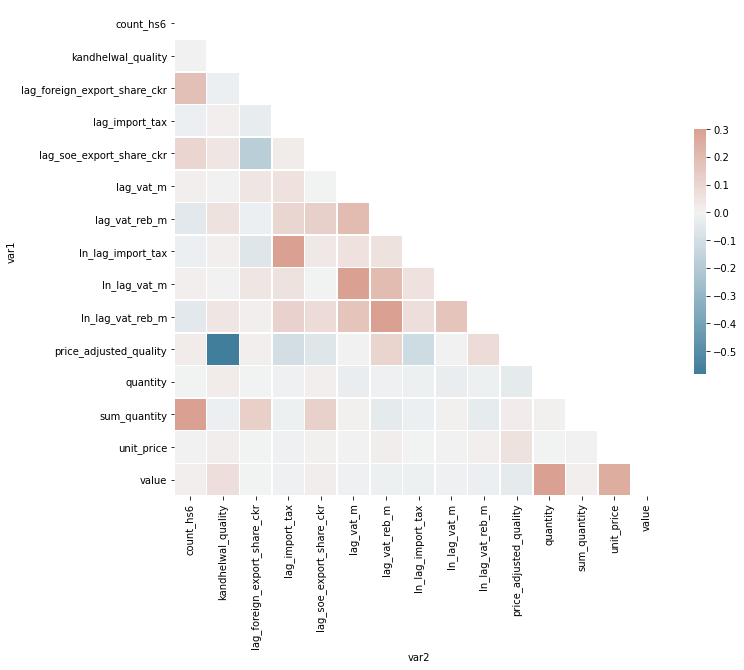

## Scatterplot

From the correlation plot above, pick up a $y$ variables.

We only plot the variables that succeed the Anova test, minus the $y$ var.

Besides, to avoid loading all the table, we have implemented the following rule:

if the size of the table is above >150K rows, then we randomly load 150K rows

First of all, you need to define the Y-axis variables

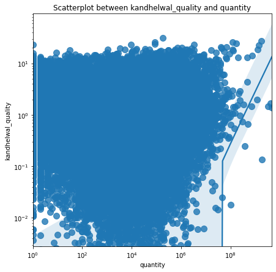

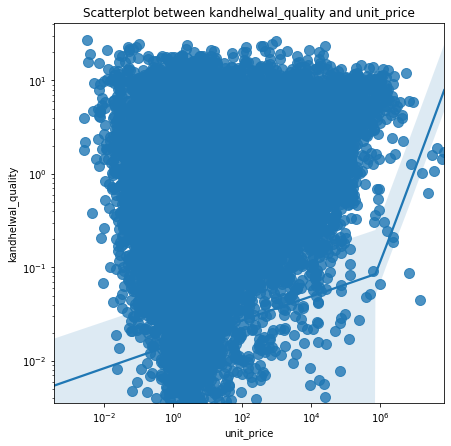

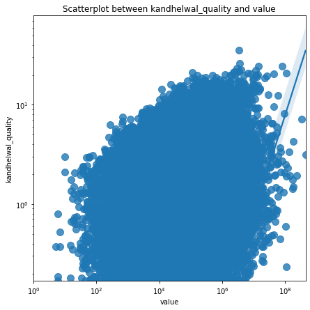

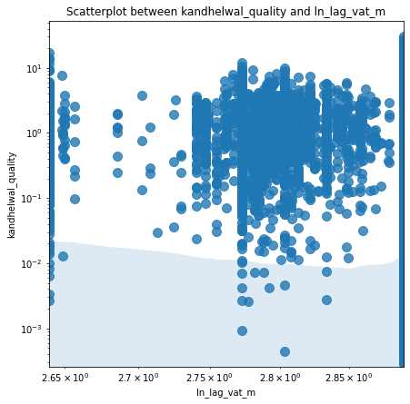

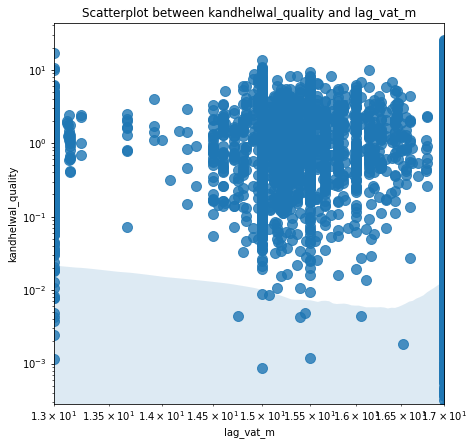

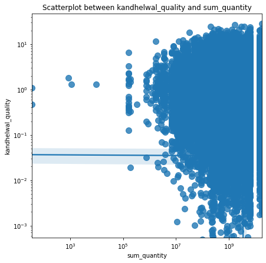

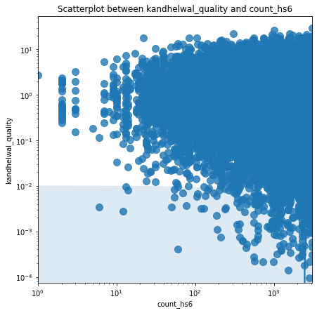

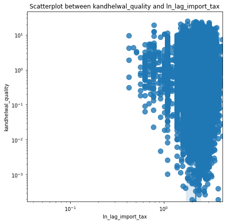

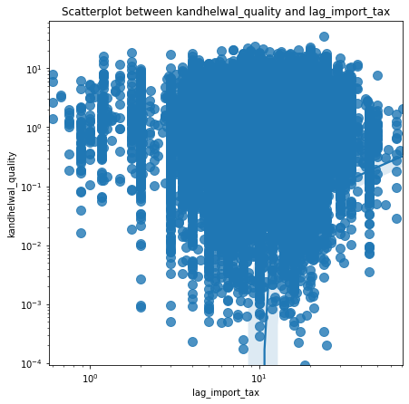

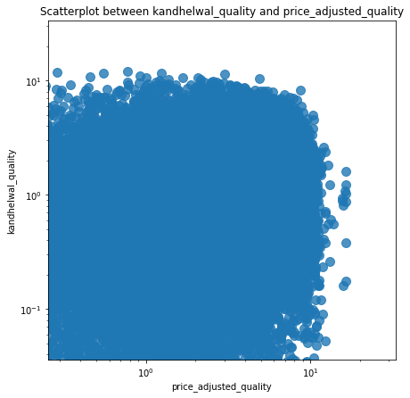

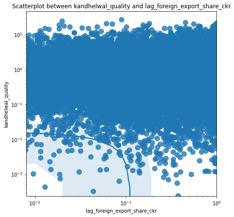

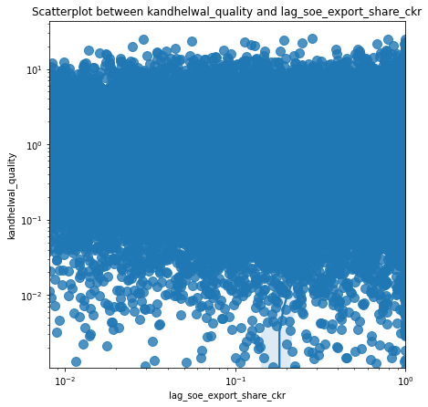

[2 more figures not shown]

### Diverging bars

The diverging bar plot is plotting for the variables to succeed the Anova test

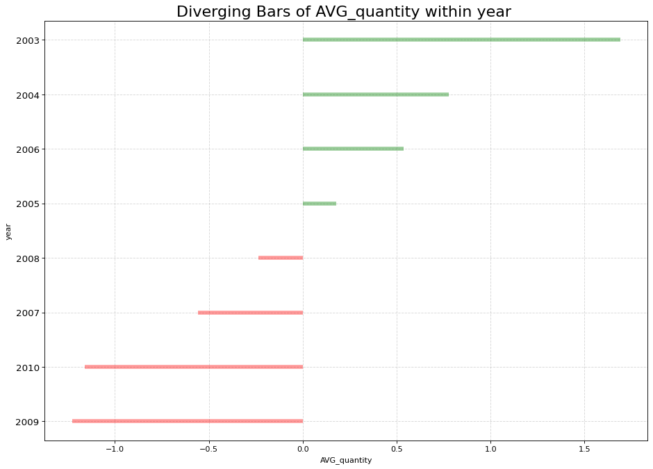

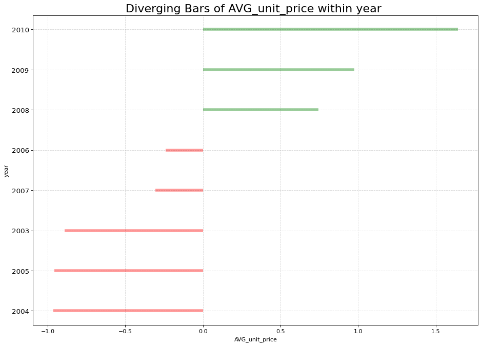

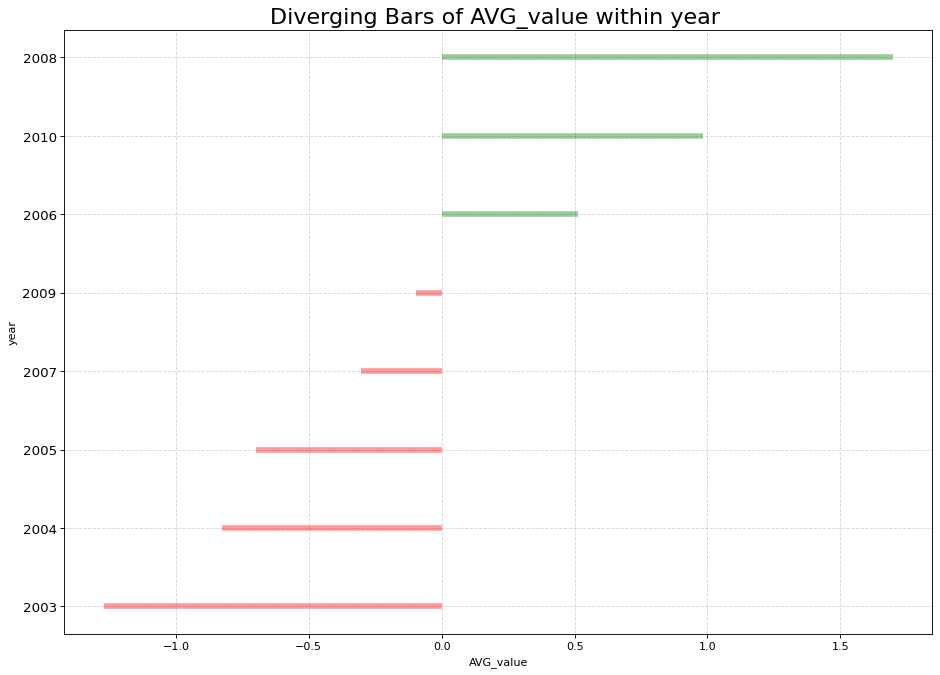

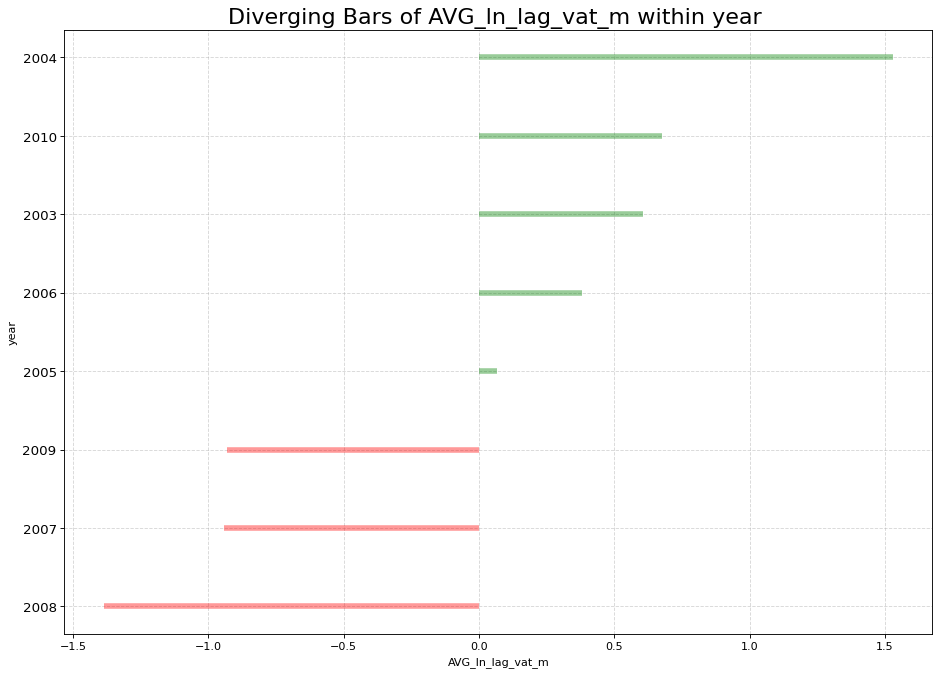

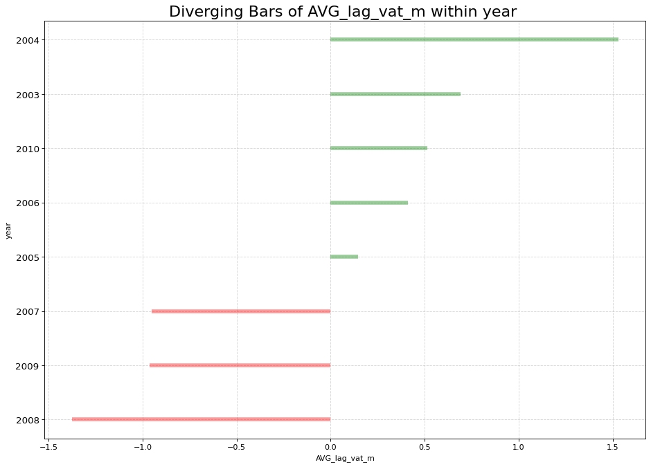

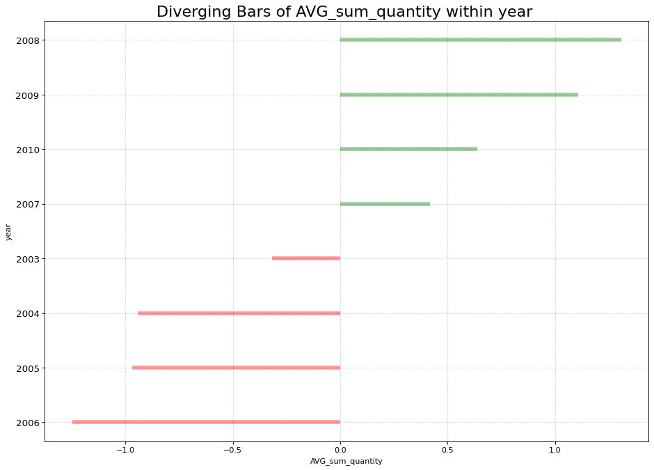

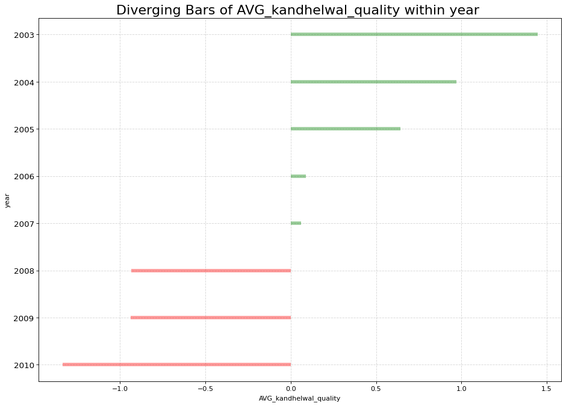

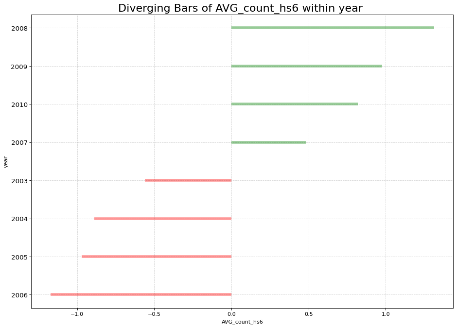

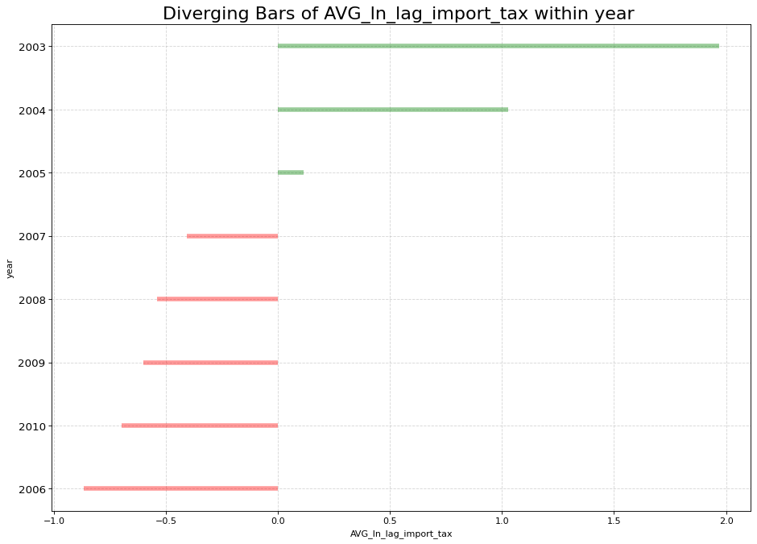

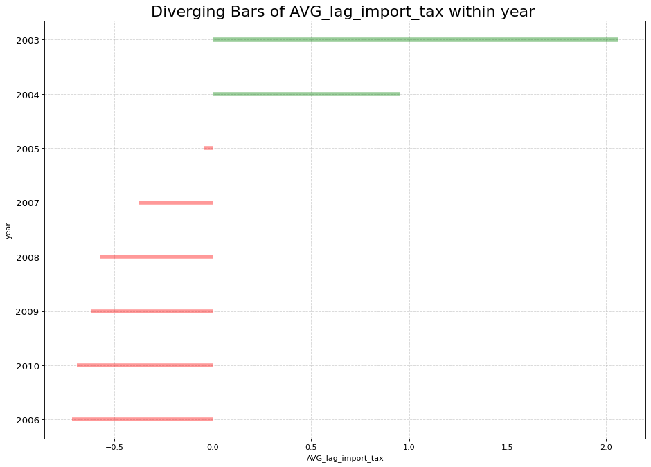

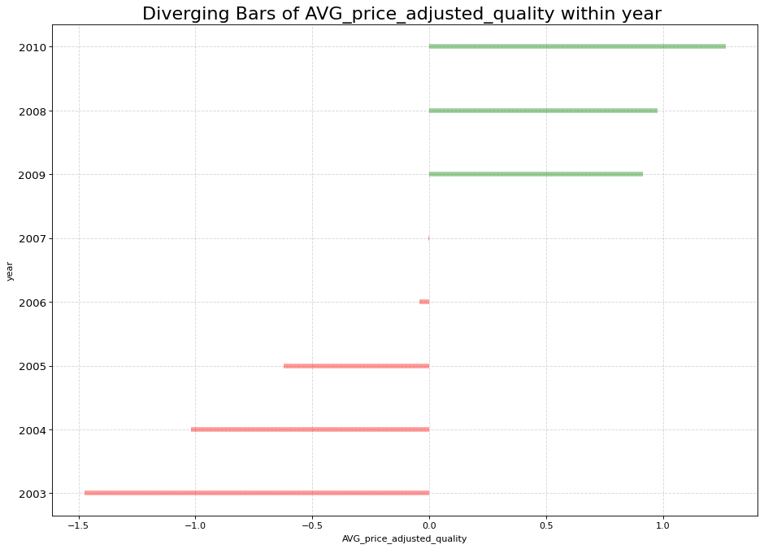

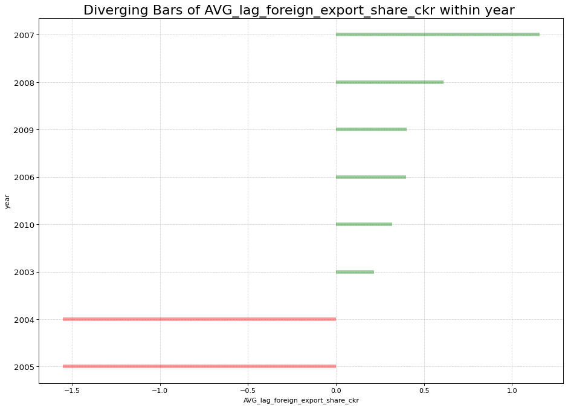

[3 more figures not shown]